# Parent_ChildExpCooperativeCompetence

Nichole Breeland

19/02/2020

##Document and Variable set up

```r
all.data$response.diff = with(all.data, Op_coop_Alt_Avg_p1 - Op_coop_Ego_Avg_p1)
```

```r
#Main data set for ORCA all study in group - moms and study in only
P1.data_pcgm <- all.data[which(all.data$Study_inout == 1 & all.data$Parent_Type_p1 == 2),]
#Main data set for ORCA all study in group moms only - Ethnicity, SES, and P5/P6 age dataframe
P1.eth<- eth.data[which(eth.data$Study_inout == 1 & eth.data$Parent_Type_p1 == 2),]
#Parallel roles study in data subset - Mothers only
PR_pcgm.data <- all.data[which(all.data$InOut_PR_P3 == 1 & all.data$Study_inout == 1 & all.data$Parent_Type_p1 == 2),]
#Froggy task study in data subset - Mothers only
FT_pcgm.data <- all.data[which(all.data$InOut_FT_P3 == 1 & all.data$Study_inout == 1 & all.data$Parent_Type_p1 == 2),]

####Parent personality datasets
#Dataset that includes mothers who completed forms at phase 5
personality.df_pcgm <- all.data[which(all.data$Study_inout == 1 & all.data$Parent_Type_p5 == 2),]

#Dataset that includes mothers completed forms at phase 1 and Phase 5
personality.values.df_pcgm <- all.data[which(all.data$Study_inout == 1 & all.data$Parent_Type_p5 == 2 & all.data$Parent_Type_p1 == 2),]

#Parallel roles study in data subset - subset of infants study in for PR Phase 3 whos mothers who completed forms at phase 1 and phase 5
PR_pcgm.data.p3.p5 <- all.data[which(all.data$InOut_PR_P3 == 1 & all.data$Study_inout == 1 & all.data$Parent_Type_p1 == 2 & all.data$Parent_Type_p5 == 2),]

#Complementary roles study in data subset - subset of infants study in for FT Phase 3 whos mothers who completed forms at phase 1 and phase 5
FT_pcgm.data.p3.p5 <- all.data[which(all.data$InOut_FT_P3 == 1 & all.data$Study_inout == 1 & all.data$Parent_Type_p1 == 2 &
                                       all.data$Parent_Type_p5 == 2),]
```

## Visualizing the data/Descriptives

### Parent SES determined by education level

```r
##Education/SES descriptives
P1.eth$Edu_P5_yn_label[P1.eth$Edu_P5_yn == 1] <- "Completed P5"
P1.eth$Edu_P5_yn_label[P1.eth$Edu_P5_yn == 0] <- "Completed P4"

#Data frequencies used from which phase. P4 data was only used if P5 data was missing as P5 had the highest completion rate
table(P1.eth$Edu_P5_yn_label)
```

```
##
## Completed P4 Completed P5
##           29          201
```

```r
P1.eth$Edu_Secondary_label[P1.eth$Parent_HighestSchoolQual_p5 == 0] <- "None"
P1.eth$Edu_Secondary_label[P1.eth$Parent_HighestSchoolQual_p5 == 1] <- "5th Form/Year 11"
P1.eth$Edu_Secondary_label[P1.eth$Parent_HighestSchoolQual_p5 == 2] <- "6th Form/Year 12/Certificate/GCSE (UK)"
P1.eth$Edu_Secondary_label[P1.eth$Parent_HighestSchoolQual_p5 == 3] <- "7th Form/Year13/Bursary/A level (UK)"
P1.eth$Edu_Secondary_label[P1.eth$Parent_HighestSchoolQual_p5 == 4] <- "Other"
P1.eth$Edu_Secondary_label[is.na(P1.eth$Parent_HighestSchoolQual_p5)] <- "Unknown/Missing"

#Secondary school completion rate
table(P1.eth$Edu_Secondary_label)
```

```
##
##                       5th Form/Year 11 6th Form/Year 12/Certificate/GCSE (UK)
##                                      5                                     43
##   7th Form/Year13/Bursary/A level (UK)                                   None
##                                    141                                      1
##                                  Other                        Unknown/Missing
##                                      1                                     39
```

```r
#Highest level of tertiary education achieved
P1.eth$Edu_Tert_label[P1.eth$Parent_otherqual_spec_p5 == 0] <- "None"
P1.eth$Edu_Tert_label[P1.eth$Parent_otherqual_spec_p5 == 1] <- "Bachelors/Diploma (up to 3 years education post secondary school)"
P1.eth$Edu_Tert_label[P1.eth$Parent_otherqual_spec_p5 == 2] <- "PostGrad/Masters (up to 5 years education post secondary school)"
P1.eth$Edu_Tert_label[P1.eth$Parent_otherqual_spec_p5 == 3] <- "PhD (more than 5 yrs education post secondary school)"
P1.eth$Edu_Tert_label[P1.eth$Parent_otherqual_spec_p5 == 4] <- "Other"
P1.eth$Edu_Tert_label[is.na(P1.eth$Parent_otherqual_spec_p5)] <- "Unknown/Missing"

table(P1.eth$Edu_Tert_label)
```

```
##
## Bachelors/Diploma (up to 3 years education post secondary school)
##                                                               122
##                                                              None
##                                                                 9
##                                                             Other
##                                                                 6
##             PhD (more than 5 yrs education post secondary school)
##                                                                 7
##  PostGrad/Masters (up to 5 years education post secondary school)
##                                                                44
##                                                   Unknown/Missing
##                                                                42
```

### Parent Cooperative Value Score (CVS) & Social Games Frequency

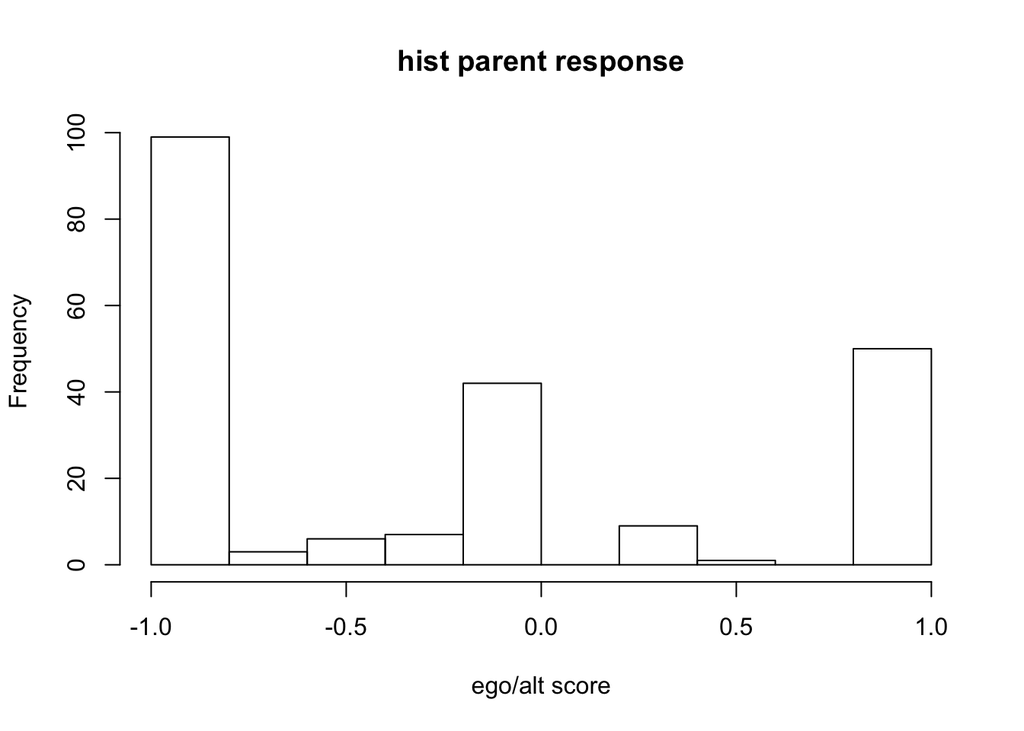

```r
with(P1.data_pcgm, hist(response.diff,breaks = 10,
                   xlab = "ego/alt score",
                   main = "hist parent response"))
```

```r
mean(P1.data_pcgm$response.diff, na.rm = TRUE)
```

```
## [1] -0.241321
```

```r
sd(P1.data_pcgm$response.diff, na.rm = TRUE)
```

```
## [1] 0.8074548
```

```r
range(P1.data_pcgm$response.diff, na.rm = TRUE)
```

```
## [1] -1  1
```

```r
# of complete observations
sum(!is.na(P1.data_pcgm$response.diff))
```

```
## [1] 217
```

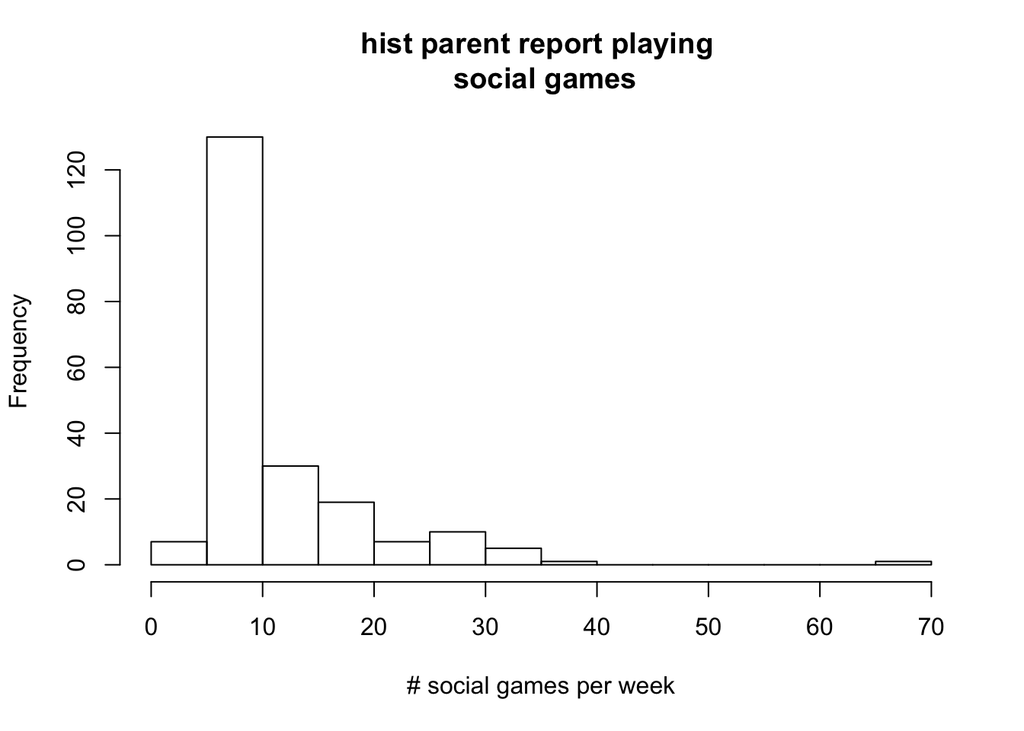

```r
with(P1.data_pcgm, hist(Pi_social_games_freq_p1_fixed,breaks = 10,
                   xlab = "# social games per week",
                   main = "hist parent report playing \n social games"))
```

```r
mean(P1.data_pcgm$Pi_social_games_freq_p1_fixed, na.rm = TRUE)
```

```
## [1] 12.00238
```

```r
sd(P1.data_pcgm$Pi_social_games_freq_p1_fixed, na.rm = TRUE)
```

```
## [1] 8.464462
```

```r
range(P1.data_pcgm$Pi_social_games_freq_p1_fixed, na.rm = TRUE)
```

```
## [1]  2 70
```

```r
# of complete observations
sum(!is.na(P1.data_pcgm$Pi_social_games_freq_p1_fixed))
```

```
## [1] 210
```

### Parent Personality Big 5 Five Factor Model (Study 1)

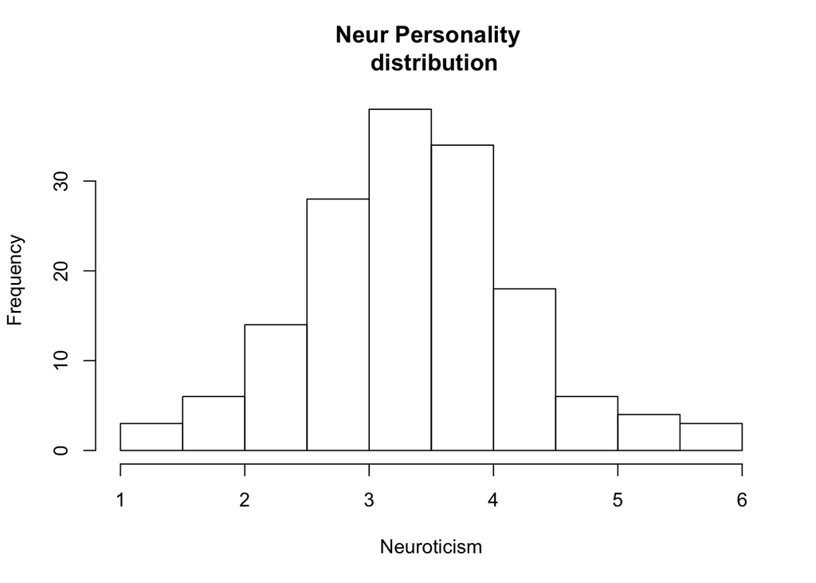

```r
#Neur
with(personality.df_pcgm, hist(Neur,breaks = 10,
                          xlab = "Neuroticism",
                          main = "Neur Personality \n distribution"))
```

```r
skewness(personality.df_pcgm$Neur, na.rm = TRUE)
```

```
## [1] 0.1287214
```

```r
shapiro.test(personality.df_pcgm$Neur)
```

```
##
##  Shapiro-Wilk normality test
##
## data:  personality.df_pcgm$Neur
## W = 0.9913, p-value = 0.4685
```

```r
mean(personality.df_pcgm$Neur, na.rm = TRUE)
```

```
## [1] 3.365222
```

```r
sd(personality.df_pcgm$Neur, na.rm = TRUE)
```

```
## [1] 0.8792038
```

```r
range(personality.df_pcgm$Neur, na.rm = TRUE)
```

```
## [1] 1.00 5.75
```

```r
# of complete observations
sum(!is.na(personality.df_pcgm$Neur))
```

```
## [1] 154
```

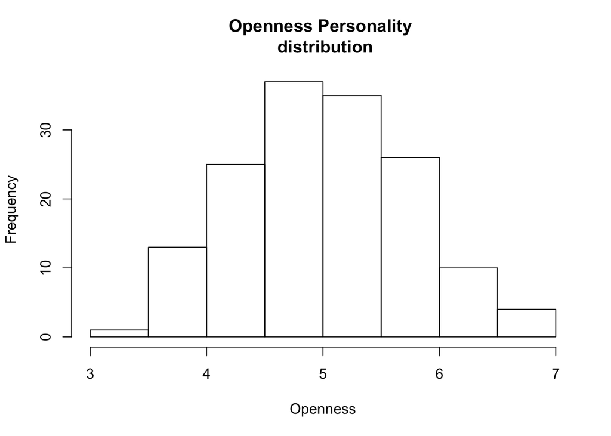

```r
#Openness
with(personality.df_pcgm, hist(Open,breaks = 10,
                          xlab = "Openness",
                          main = "Openness Personality \n distribution"))
```

```r
skewness(personality.df_pcgm$Open, na.rm = TRUE)
```

```
## [1] 0.07047482
```

```r
shapiro.test(personality.df_pcgm$Open)
```

```
##
##  Shapiro-Wilk normality test
##
## data:  personality.df_pcgm$Open
## W = 0.99395, p-value = 0.7835
```

```r
mean(personality.df_pcgm$Open, na.rm = TRUE)
```

```
## [1] 5.032867
```

```r
sd(personality.df_pcgm$Open, na.rm = TRUE)
```

```
## [1] 0.7355323
```

```r
range(personality.df_pcgm$Open, na.rm = TRUE)
```

```
## [1] 3.2 6.9
```

```r
# of complete observations
sum(!is.na(personality.df_pcgm$Open))
```

```
## [1] 151
```

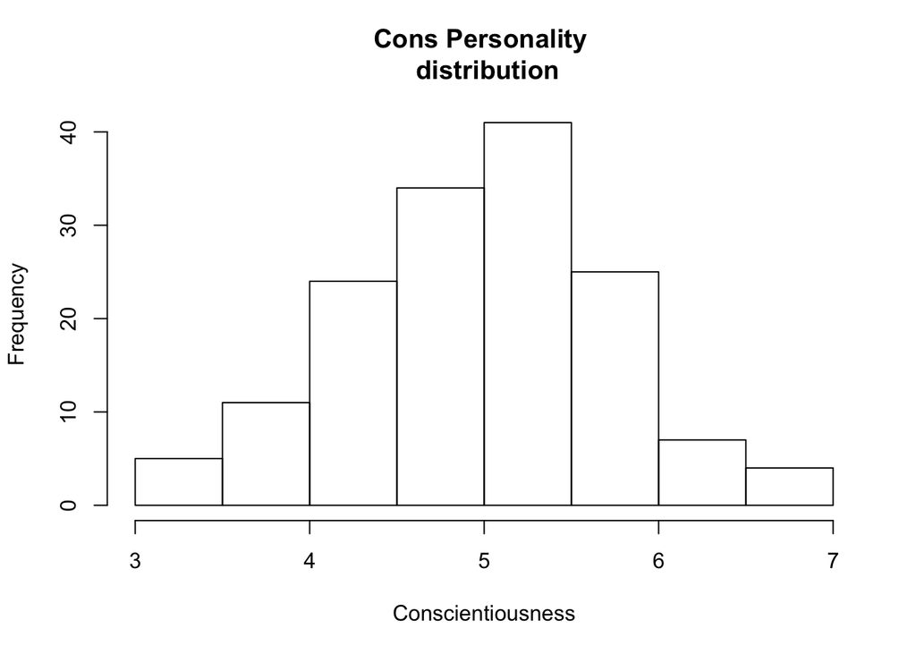

```r
#Conscientiousness

with(personality.df_pcgm, hist(Cons,breaks = 10,
                          xlab = "Conscientiousness",
                          main = "Cons Personality \n distribution"))
```

```r
skewness(personality.df_pcgm$Cons, na.rm = TRUE)
```

```
## [1] -0.1142968
```

```r
shapiro.test(personality.df_pcgm$Cons)
```

```
##
##  Shapiro-Wilk normality test
##
## data:  personality.df_pcgm$Cons
## W = 0.9958, p-value = 0.9466
```

```r
mean(personality.df_pcgm$Cons, na.rm = TRUE)
```

```
## [1] 4.993691
```

```r
sd(personality.df_pcgm$Cons, na.rm = TRUE)
```

```
## [1] 0.7458861
```

```r
range(personality.df_pcgm$Cons, na.rm = TRUE)
```

```
## [1] 3.0 6.9
```

```r
# of complete observations
sum(!is.na(personality.df_pcgm$Cons))
```

```
## [1] 151
```

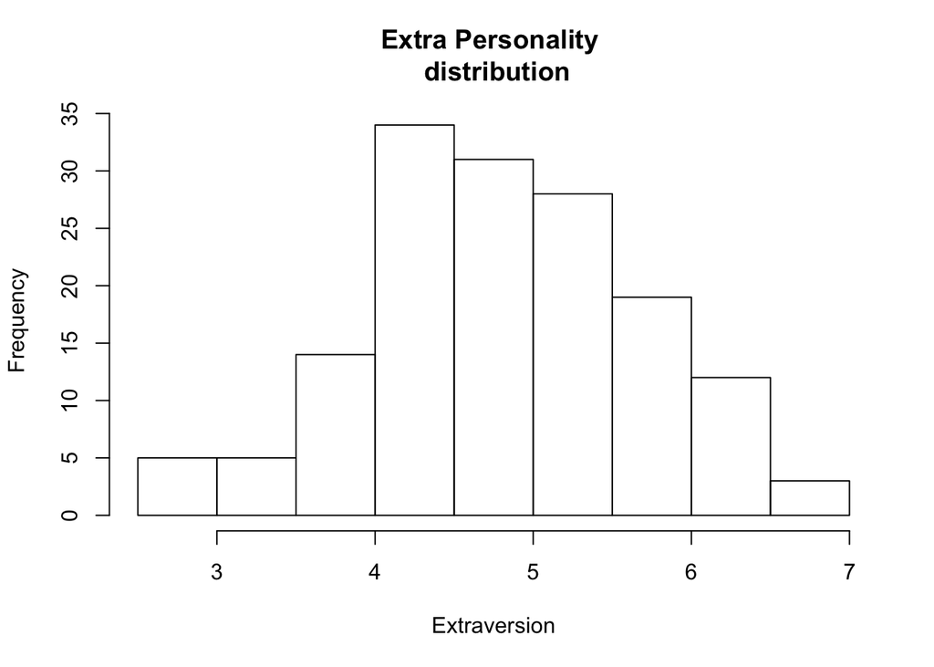

```r
#Extraversion
with(personality.df_pcgm, hist(Extra,breaks = 10,
                          xlab = "Extraversion",
                          main = "Extra Personality \n distribution"))
```

```r
skewness(personality.df_pcgm$Extra, na.rm = TRUE)
```

```
## [1] -0.0302315
```

```r
shapiro.test(personality.df_pcgm$Extra)
```

```
##
##  Shapiro-Wilk normality test
##
## data:  personality.df_pcgm$Extra
## W = 0.99268, p-value = 0.6371
```

```r
mean(personality.df_pcgm$Extra, na.rm = TRUE)
```

```
## [1] 4.836616
```

```r
sd(personality.df_pcgm$Extra, na.rm = TRUE)
```

```
## [1] 0.8700926
```

```r
range(personality.df_pcgm$Extra, na.rm = TRUE)
```

```
## [1] 2.85 7.00
```

```r
# of complete observations
sum(!is.na(personality.df_pcgm$Extra))
```

```
## [1] 151
```

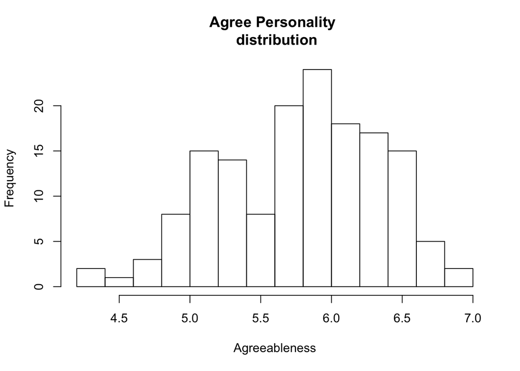

```r
#Agreeableness
with(personality.df_pcgm, hist(Agree,breaks = 10,
                               xlab = "Agreeableness",
                               main = "Agree Personality \n distribution"))
```

```r
skewness(personality.df_pcgm$Agree, na.rm = TRUE)
```

```
## [1] -0.3688659
```

```r
shapiro.test(personality.df_pcgm$Agree)
```

```
##
##  Shapiro-Wilk normality test
##
## data:  personality.df_pcgm$Agree
## W = 0.98065, p-value = 0.03097
```

```r
mean(personality.df_pcgm$Agree, na.rm = TRUE)
```

```
## [1] 5.814597
```

```r
sd(personality.df_pcgm$Agree, na.rm = TRUE)
```

```
## [1] 0.5610306
```

```r
range(personality.df_pcgm$Agree, na.rm = TRUE)
```

```
## [1] 4.25 6.90
```

```r
# of complete observations
sum(!is.na(personality.df_pcgm$Agree))
```

```
## [1] 152
```

### Parent Personality Six Factor Model (IPIP-6) Study 2

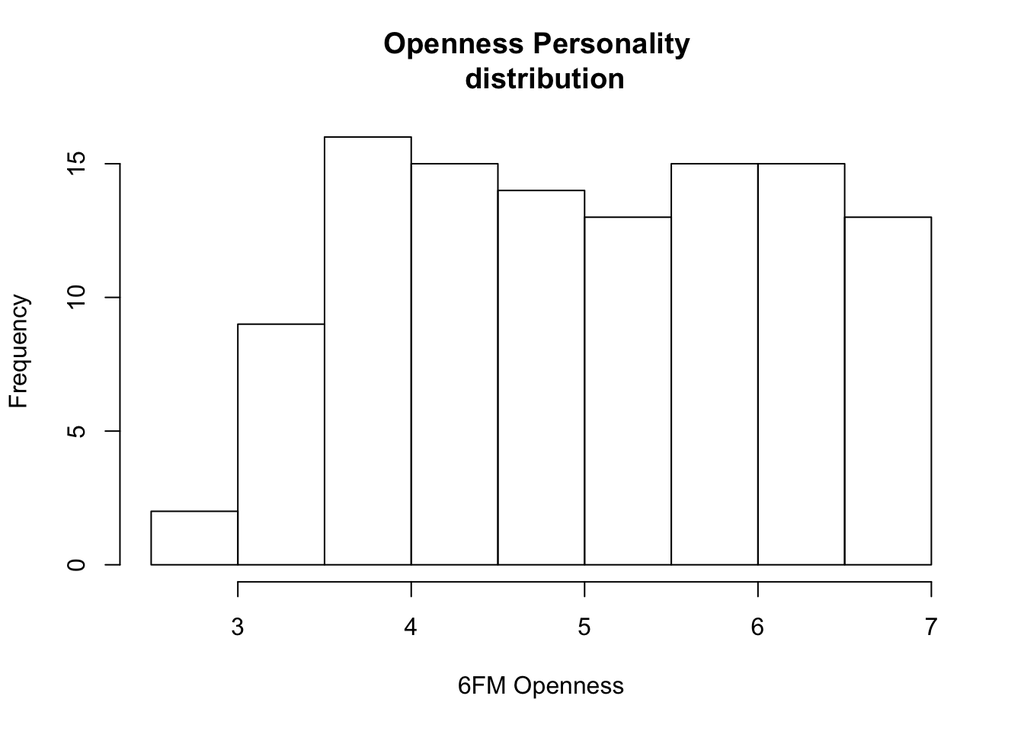

```r
#Openness
with(personality.df_pcgm, hist(IPIP6_Open,breaks = 10,
                               xlab = "6FM Openness",
                               main = "Openness Personality \n distribution"))
```

```r
skewness(personality.df_pcgm$IPIP6_Open, na.rm = TRUE)
```

```
## [1] -0.08195069
```

```r
shapiro.test(personality.df_pcgm$IPIP6_Open)
```

```
##
##  Shapiro-Wilk normality test
##
## data:  personality.df_pcgm$IPIP6_Open
## W = 0.95968, p-value = 0.001888
```

```r
mean(personality.df_pcgm$IPIP6_Open, na.rm = TRUE)
```

```
## [1] 5.136161
```

```r
sd(personality.df_pcgm$IPIP6_Open, na.rm = TRUE)
```

```
## [1] 1.127007
```

```r
range(personality.df_pcgm$IPIP6_Open, na.rm = TRUE)
```

```
## [1] 2.5 7.0
```

```r
# of complete observations
sum(!is.na(personality.df_pcgm$IPIP6_Open))
```

```
## [1] 112
```

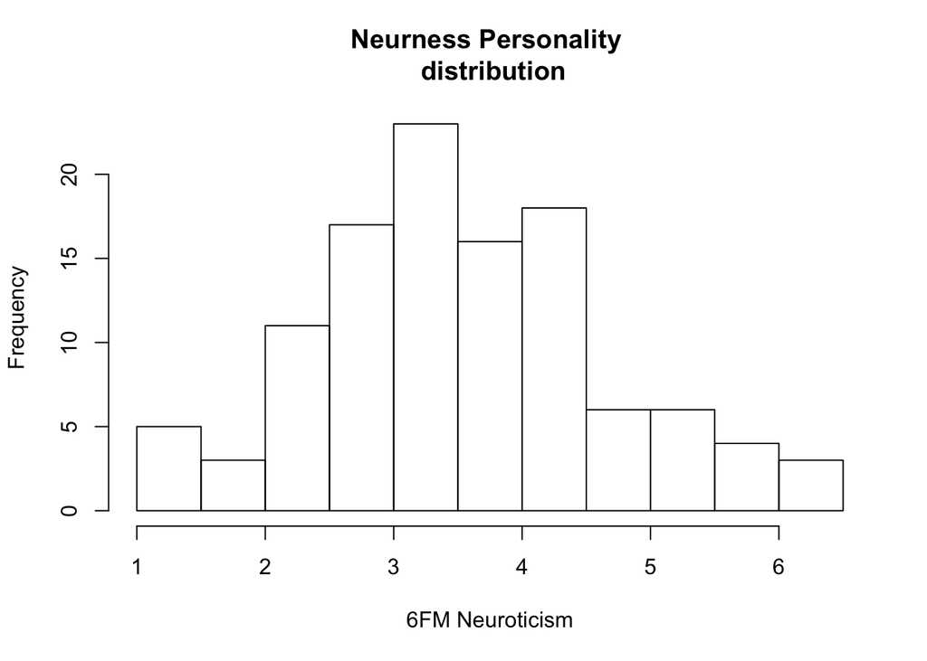

```r
#Neuroticism
with(personality.df_pcgm, hist(IPIP6_Neur,breaks = 10,
                               xlab = "6FM Neuroticism",
                               main = "Neurness Personality \n distribution"))
```

```r
skewness(personality.df_pcgm$IPIP6_Neur, na.rm = TRUE)
```

```
## [1] 0.1946773
```

```r
shapiro.test(personality.df_pcgm$IPIP6_Neur)
```

```
##
##  Shapiro-Wilk normality test
##
## data:  personality.df_pcgm$IPIP6_Neur
## W = 0.98168, p-value = 0.128
```

```r
mean(personality.df_pcgm$IPIP6_Neur, na.rm = TRUE)
```

```
## [1] 3.642113
```

```r
sd(personality.df_pcgm$IPIP6_Neur, na.rm = TRUE)
```

```
## [1] 1.120194
```

```r
range(personality.df_pcgm$IPIP6_Neur, na.rm = TRUE)
```

```
## [1] 1.25 6.25
```

```r
# of complete observations
sum(!is.na(personality.df_pcgm$IPIP6_Neur))
```

```
## [1] 112
```

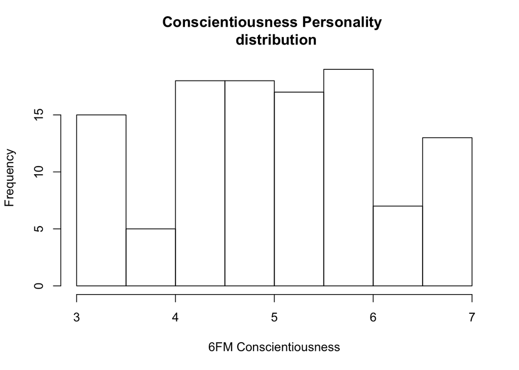

```r
#Conscientiousness
with(personality.df_pcgm, hist(IPIP6_Cons,breaks = 10,
                               xlab = "6FM Conscientiousness",
                               main = "Conscientiousness Personality \n distribution"))
```

```r
skewness(personality.df_pcgm$IPIP6_Cons, na.rm = TRUE)
```

```
## [1] -0.08911808
```

```r
shapiro.test(personality.df_pcgm$IPIP6_Cons)
```

```
##
##  Shapiro-Wilk normality test
##
## data:  personality.df_pcgm$IPIP6_Cons
## W = 0.96783, p-value = 0.008362
```

```r
mean(personality.df_pcgm$IPIP6_Cons, na.rm = TRUE)
```

```
## [1] 5.109375
```

```r
sd(personality.df_pcgm$IPIP6_Cons, na.rm = TRUE)
```

```
## [1] 1.104751
```

```r
range(personality.df_pcgm$IPIP6_Cons, na.rm = TRUE)
```

```
## [1] 3 7
```

```r
# of complete observations
sum(!is.na(personality.df_pcgm$IPIP6_Cons))
```

```
## [1] 112
```

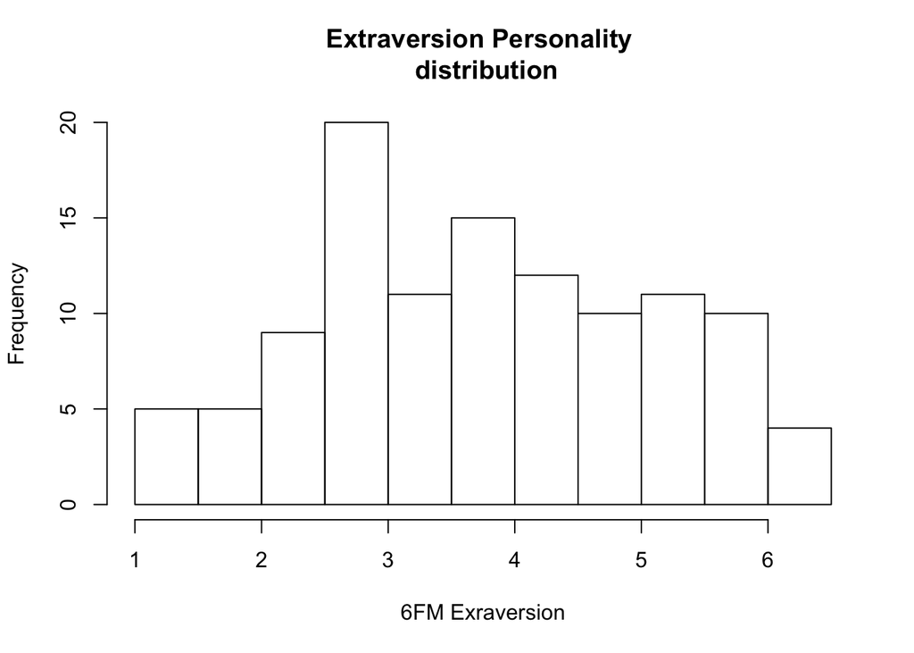

```r
#Extra
with(personality.df_pcgm, hist(IPIP6_Extra,breaks = 10,
                               xlab = "6FM Exraversion",
                               main = "Extraversion Personality \n distribution"))
```

```r
skewness(personality.df_pcgm$IPIP6_Extra, na.rm = TRUE)
```

```
## [1] 0.04741102
```

```r
shapiro.test(personality.df_pcgm$IPIP6_Extra)
```

```
##
##  Shapiro-Wilk normality test
##
## data:  personality.df_pcgm$IPIP6_Extra
## W = 0.97006, p-value = 0.0128
```

```r
mean(personality.df_pcgm$IPIP6_Extra, na.rm = TRUE)
```

```
## [1] 3.897321
```

```r
sd(personality.df_pcgm$IPIP6_Extra, na.rm = TRUE)
```

```
## [1] 1.333708
```

```r
range(personality.df_pcgm$IPIP6_Extra, na.rm = TRUE)
```

```
## [1] 1.25 6.50
```

```r
# of complete observations
sum(!is.na(personality.df_pcgm$IPIP6_Extra))
```

```
## [1] 112
```

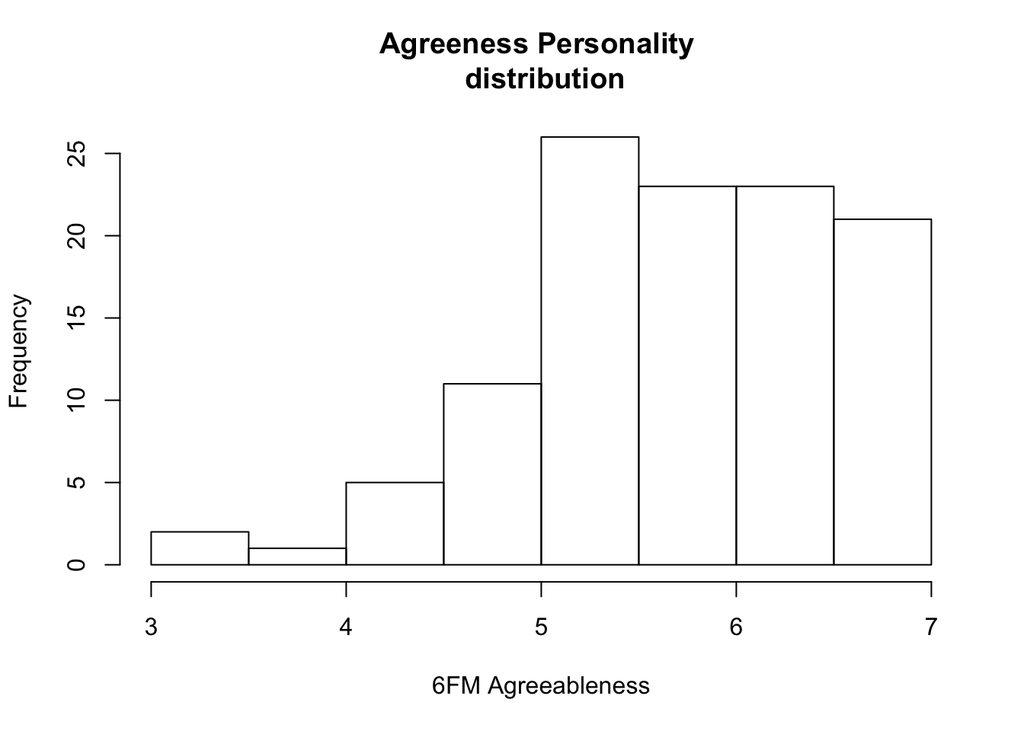

```r
#Agreeableness
with(personality.df_pcgm, hist(IPIP6_Agree,breaks = 10,
                               xlab = "6FM Agreeableness",
                               main = "Agreeness Personality \n distribution"))
```

```r
skewness(personality.df_pcgm$IPIP6_Agree, na.rm = TRUE)
```

```
## [1] -0.579863
```

```r
shapiro.test(personality.df_pcgm$IPIP6_Agree)
```

```
##
##  Shapiro-Wilk normality test
##
## data:  personality.df_pcgm$IPIP6_Agree
## W = 0.95311, p-value = 0.0006116
```

```r
mean(personality.df_pcgm$IPIP6_Agree, na.rm = TRUE)
```

```
## [1] 5.834821
```

```r
sd(personality.df_pcgm$IPIP6_Agree, na.rm = TRUE)
```

```
## [1] 0.8029742
```

```r
range(personality.df_pcgm$IPIP6_Agree, na.rm = TRUE)
```

```
## [1] 3.25 7.00
```

```r
# of complete observations
sum(!is.na(personality.df_pcgm$IPIP6_Agree))
```

```
## [1] 112
```

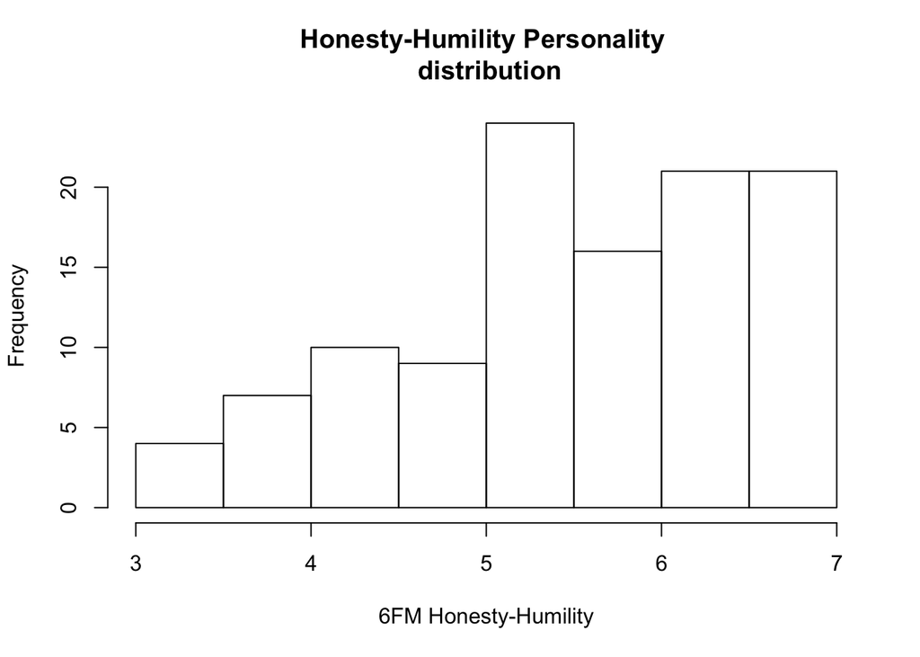

```r
#Honesty-Humility
with(personality.df_pcgm, hist(IPIP6_HonHum,breaks = 10,
                               xlab = "6FM Honesty-Humility",
                               main = "Honesty-Humility Personality \n distribution"))
```

```r
skewness(personality.df_pcgm$IPIP6_HonHum, na.rm = TRUE)
```

```
## [1] -0.5461185
```

```r
shapiro.test(personality.df_pcgm$IPIP6_HonHum)
```

```
##
##  Shapiro-Wilk normality test
##
## data:  personality.df_pcgm$IPIP6_HonHum
## W = 0.94275, p-value = 0.0001171
```

```r
mean(personality.df_pcgm$IPIP6_HonHum, na.rm = TRUE)
```

```
## [1] 5.618304
```

```r
sd(personality.df_pcgm$IPIP6_HonHum, na.rm = TRUE)
```

```
## [1] 1.006152
```

```r
range(personality.df_pcgm$IPIP6_HonHum, na.rm = TRUE)
```

```
## [1] 3 7
```

```r
# of complete observations
sum(!is.na(personality.df_pcgm$IPIP6_HonHum))
```

```
## [1] 112
```

### Infant Age by Phase

```r
#Phase 1
mean(P1.data_pcgm$Age_p1, na.rm=TRUE)
```

```
## [1] 9.975725
```

```r
sd(P1.data_pcgm$Age_p1, na.rm=TRUE)
```

```
## [1] 0.4215818
```

```r
range(P1.data_pcgm$Age_p1, na.rm=TRUE)
```

```
## [1]  9.066667 11.000000
```

```r
#Phase 3
mean(P1.data_pcgm$Age_p3, na.rm = TRUE)
```

```
## [1] 14.29205
```

```r
sd(P1.data_pcgm$Age_p3, na.rm = TRUE)
```

```
## [1] 0.6331593
```

```r
range(P1.data_pcgm$Age_p3, na.rm = TRUE)
```

```
## [1] 13.03 16.77
```

```r
#Phase 5
mean(P1.eth$P5_Age, na.rm = TRUE)
```

```
## [1] 36.20875
```

```r
sd(P1.eth$P5_Age, na.rm = TRUE)
```

```
## [1] 1.856821
```

```r
range(P1.eth$P5_Age, na.rm = TRUE)
```

```
## [1] 32.33 49.00
```

```r
#Phase 6
mean(P1.eth$P6_Age, na.rm = TRUE)
```

```
## [1] 52.86907
```

```r
sd(P1.eth$P6_Age, na.rm = TRUE)
```

```
## [1] 6.352364
```

```r
range(P1.eth$P6_Age, na.rm = TRUE)
```

```
## [1] 45.43 73.27
```

### Infant Gender (P1)

```r
table(P1.data_pcgm$Gender_Label)
```

```
##
## Female   Male
##    104    126
```

### Infant Ethnicity

```r
#Ethnicity categories
#NZE = 1
#NZE/Maori =2
#NZE/Asian = 3
#NZE/Other = 4
#Other = 5
#NZE/Maori/Other = 6

P1.eth$Eth_Cat[P1.eth$NZEur_p1 == 1 & P1.eth$Maori_p1 == 0
               & P1.eth$Asian_p1 == 0 & P1.eth$Pacific_p1 == 0
               & P1.eth$MidEastLatAmAfrican_p1 == 0 & P1.eth$OtherEur_p1 == 0
               & P1.eth$Other_p1 == 0] <- 1

P1.eth$Eth_Cat[P1.eth$NZEur_p1 == 1 & P1.eth$Maori_p1 == 1
               & P1.eth$Asian_p1 == 0 & P1.eth$Pacific_p1 == 0
               & P1.eth$MidEastLatAmAfrican_p1 == 0 & P1.eth$OtherEur_p1 == 0
               & P1.eth$Other_p1 == 0] <- 2

P1.eth$Eth_Cat[P1.eth$NZEur_p1 == 1 & P1.eth$Maori_p1 == 0
               & P1.eth$Asian_p1 == 1 & P1.eth$Pacific_p1 == 0
               & P1.eth$MidEastLatAmAfrican_p1 == 0 & P1.eth$OtherEur_p1 == 0
               & P1.eth$Other_p1 == 0] <- 3

P1.eth$Eth_Cat[P1.eth$NZEur_p1 == 1 & P1.eth$Maori_p1 == 0
               & P1.eth$Asian_p1 == 0 & P1.eth$Pacific_p1 == 0
               & P1.eth$MidEastLatAmAfrican_p1 == 0 & P1.eth$OtherEur_p1 == 0
               & P1.eth$Other_p1 == 1] <- 4

P1.eth$Eth_Cat[P1.eth$NZEur_p1 == 1 & P1.eth$Maori_p1 == 1
               & P1.eth$Asian_p1 == 0 & P1.eth$Pacific_p1 == 0
               & P1.eth$MidEastLatAmAfrican_p1 == 0 & P1.eth$OtherEur_p1 == 0
               & P1.eth$Other_p1 == 1] <- 6

P1.eth$Eth_Cat[is.na(P1.eth$Eth_Cat)] <- 5

P1.eth$Eth_CatLabel[P1.eth$Eth_Cat == 1] <- "NZE"
P1.eth$Eth_CatLabel[P1.eth$Eth_Cat == 2] <- "NZE/Maori"
P1.eth$Eth_CatLabel[P1.eth$Eth_Cat == 3] <- "NZE/Asian"
P1.eth$Eth_CatLabel[P1.eth$Eth_Cat == 4] <- "NZE/Other"
P1.eth$Eth_CatLabel[P1.eth$Eth_Cat == 5] <- "Other"
P1.eth$Eth_CatLabel[P1.eth$Eth_Cat == 6] <- "NZE/Maori/Other"

table(P1.eth$Eth_CatLabel)
```

```
##
##       NZE NZE/Asian NZE/Maori     Other
##       156        15        22        37
```

### Infant Cooperative Understanding (Infant Anticipation P3)

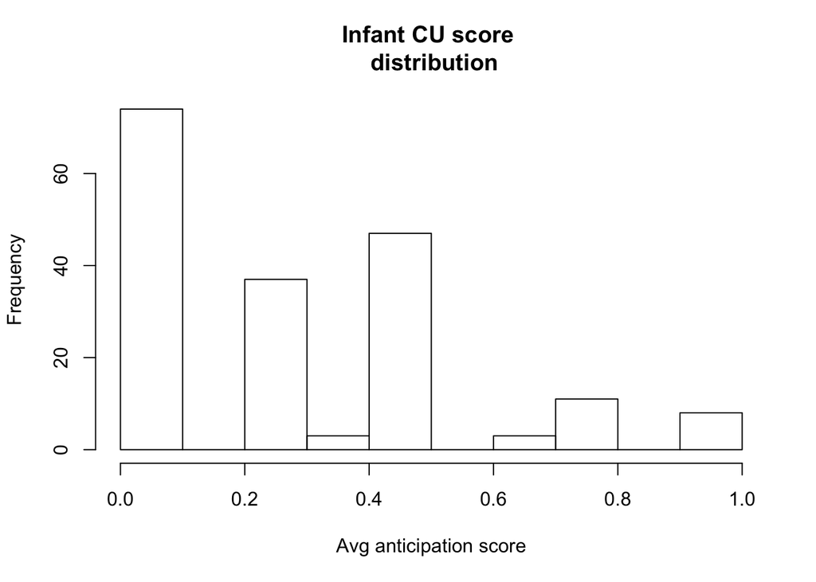

```r
with(P1.data_pcgm, hist(Avg_Anti_P3,breaks = 10,
                               xlab = "Avg anticipation score",
                               main = "Infant CU score \n distribution"))
```

```r
skewness(P1.data_pcgm$Avg_Anti_P3, na.rm = TRUE)
```

```
## [1] 0.6805472
```

```r
shapiro.test(P1.data_pcgm$Avg_Anti_P3)
```

```
##
##  Shapiro-Wilk normality test
##
## data:  P1.data_pcgm$Avg_Anti_P3
## W = 0.84082, p-value = 0.0000000000007298
```

```r
mean(P1.data_pcgm$Avg_Anti_P3, na.rm = TRUE)
```

```
## [1] 0.284153
```

```r
sd(P1.data_pcgm$Avg_Anti_P3, na.rm = TRUE)
```

```
## [1] 0.288428
```

```r
range(P1.data_pcgm$Avg_Anti_P3, na.rm = TRUE)
```

```
## [1] 0 1
```

```r
# of complete observations
sum(!is.na(P1.data_pcgm$Avg_Anti_P3))
```

```
## [1] 183
```

### Infant Cooperative Ability - Parallel Roles Task

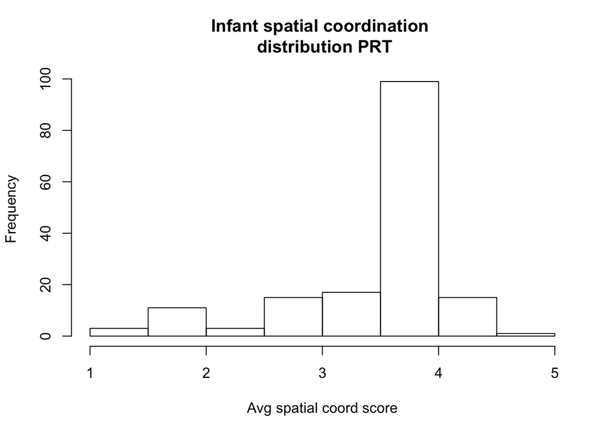

```r
#Parallel roles - Spatial Coordination
with(PR_pcgm.data, hist(Avg_SC_PR_P3,breaks = 10,
                               xlab = "Avg spatial coord score",
                               main = "Infant spatial coordination \n distribution PRT"))
```

```r
skewness(PR_pcgm.data$Avg_SC_PR_P3, na.rm = TRUE)
```

```
## [1] -1.667792
```

```r
shapiro.test(PR_pcgm.data$Avg_SC_PR_P3)
```

```
##
##  Shapiro-Wilk normality test
##
## data:  PR_pcgm.data$Avg_SC_PR_P3
## W = 0.73601, p-value = 0.0000000000000007621
```

```r
mean(PR_pcgm.data$Avg_SC_PR_P3, na.rm = TRUE)
```

```
## [1] 3.695122
```

```r
sd(PR_pcgm.data$Avg_SC_PR_P3, na.rm = TRUE)
```

```
## [1] 0.7168271
```

```r
sum(!is.na(PR_pcgm.data$Avg_SC_PR_P3))
```

```
## [1] 164
```

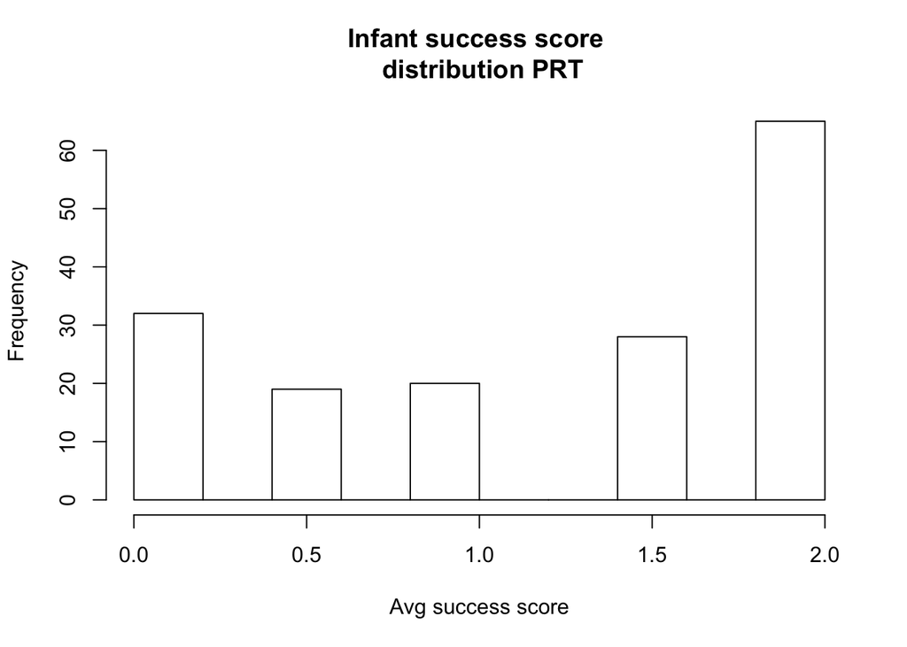

```r
#Parallel roles - Success
with(PR_pcgm.data, hist(Avg_Succ_PR_P3,breaks = 10,
                               xlab = "Avg success score",
                               main = "Infant success score \n distribution PRT"))
```

```r
skewness(PR_pcgm.data$Avg_Succ_PR_P3, na.rm = TRUE)
```

```
## [1] -0.4626211
```

```r
shapiro.test(PR_pcgm.data$Avg_Succ_PR_P3)
```

```
##
##  Shapiro-Wilk normality test
##
## data:  PR_pcgm.data$Avg_Succ_PR_P3
## W = 0.8108, p-value = 0.0000000000002671
```

```r
mean(PR_pcgm.data$Avg_Succ_PR_P3, na.rm = TRUE)
```

```
## [1] 1.228659
```

```r
sd(PR_pcgm.data$Avg_Succ_PR_P3, na.rm = TRUE)
```

```
## [1] 0.7839467
```

```r
sum(!is.na(PR_pcgm.data$Avg_Succ_PR_P3))
```

```
## [1] 164
```

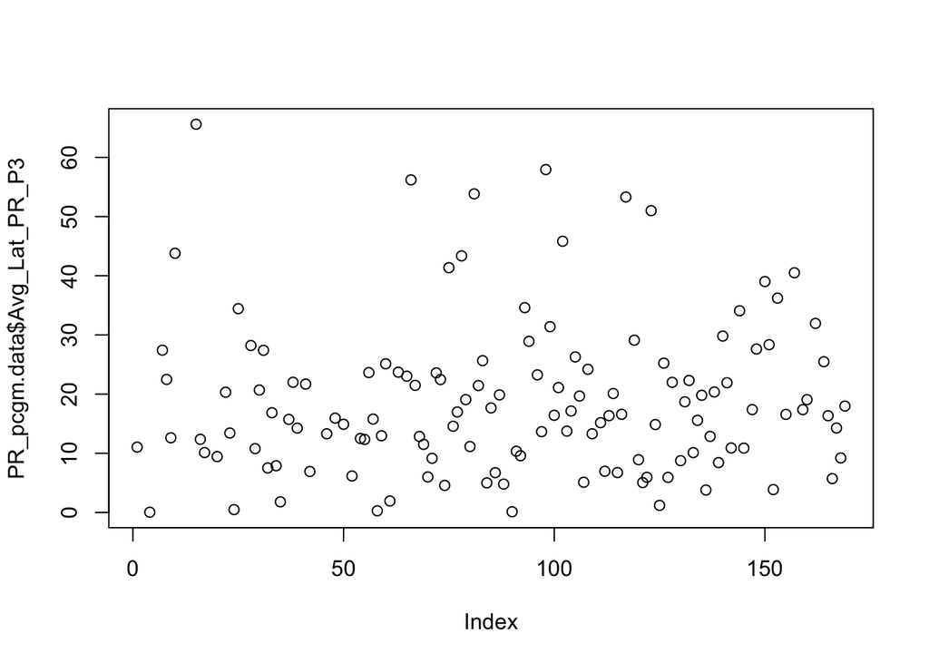

```r
#Parallel roles - Latency to success

plot(PR_pcgm.data$Avg_Lat_PR_P3)
```

```r
mean(PR_pcgm.data$Avg_Lat_PR_P3, na.rm = TRUE)
```

```
## [1] 18.85132
```

```r
sd(PR_pcgm.data$Avg_Lat_PR_P3, na.rm = TRUE)
```

```
## [1] 12.85811
```

```r
sum(!is.na(PR_pcgm.data$Avg_Lat_PR_P3))
```

```
## [1] 132
```

### Infant Cooperative Ability - Complementary Roles Task

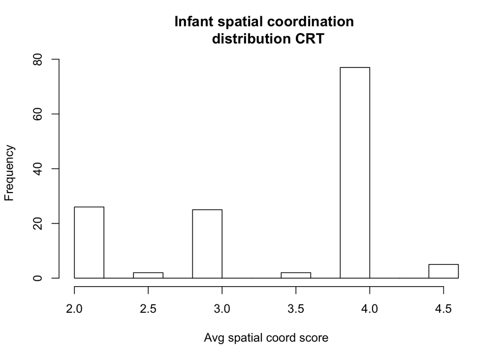

```r
#Complementary roles - Spatial Coordination
with(FT_pcgm.data, hist(Avg_SC_FT_P3,breaks = 10,
                               xlab = "Avg spatial coord score",
                               main = "Infant spatial coordination \n distribution CRT"))
```

```r
skewness(FT_pcgm.data$Avg_SC_FT_P3, na.rm = TRUE)
```

```
## [1] -0.788687
```

```r
shapiro.test(FT_pcgm.data$Avg_SC_FT_P3)
```

```
##
##  Shapiro-Wilk normality test
##
## data:  FT_pcgm.data$Avg_SC_FT_P3
## W = 0.74809, p-value = 0.00000000000004781
```

```r
mean(FT_pcgm.data$Avg_SC_FT_P3, na.rm = TRUE)
```

```
## [1] 3.427007
```

```r
sd(FT_pcgm.data$Avg_SC_FT_P3, na.rm = TRUE)
```

```
## [1] 0.8147089
```

```r
sum(!is.na(FT_pcgm.data$Avg_SC_FT_P3))
```

```
## [1] 137
```

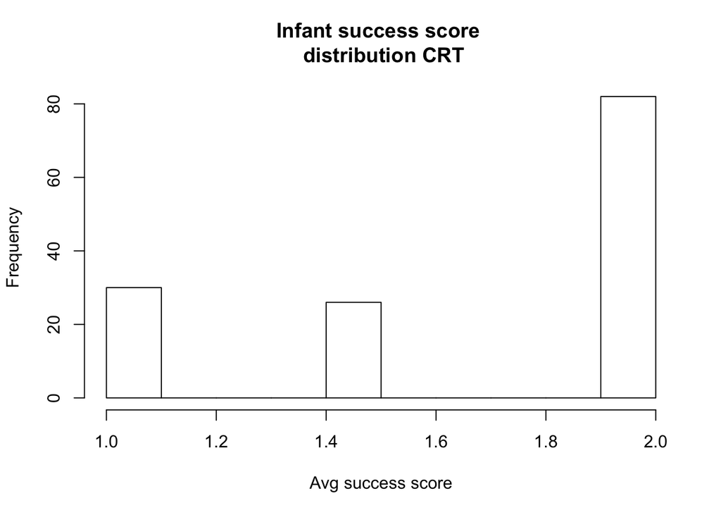

```r
#Complementary roles - Success
with(FT_pcgm.data, hist(Avg_Succ_FT_P3,breaks = 10,
                               xlab = "Avg success score",
                               main = "Infant success score \n distribution CRT"))
```

```r
skewness(FT_pcgm.data$Avg_Succ_FT_P3, na.rm = TRUE)
```

```
## [1] -0.7828155
```

```r
shapiro.test(FT_pcgm.data$Avg_Succ_FT_P3)
```

```
##
##  Shapiro-Wilk normality test
##
## data:  FT_pcgm.data$Avg_Succ_FT_P3
## W = 0.69398, p-value = 0.000000000000001363
```

```r
mean(FT_pcgm.data$Avg_Succ_FT_P3, na.rm = TRUE)
```

```
## [1] 1.688406
```

```r
sd(FT_pcgm.data$Avg_Succ_FT_P3, na.rm = TRUE)
```

```
## [1] 0.4106382
```

```r
sum(!is.na(FT_pcgm.data$Avg_Succ_FT_P3))
```

```
## [1] 138
```

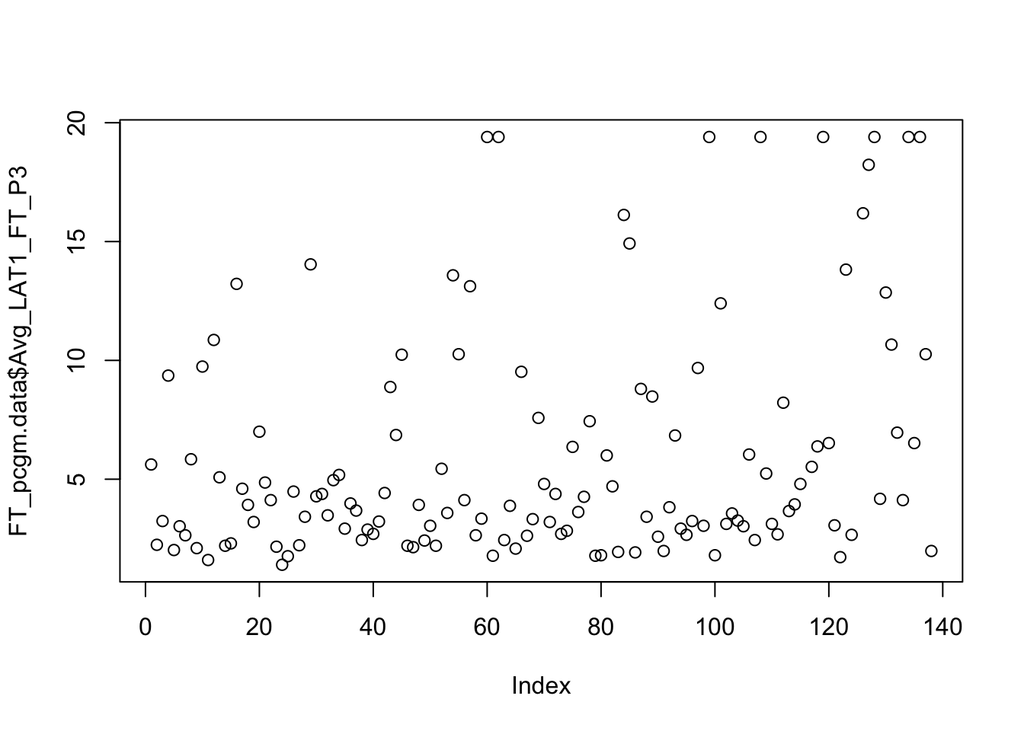

```r
#Complementary roles - Latency to success action 1

plot(FT_pcgm.data$Avg_LAT1_FT_P3)
```

```r
mean(FT_pcgm.data$Avg_LAT1_FT_P3, na.rm = TRUE)
```

```
## [1] 6.017243
```

```r
sd(FT_pcgm.data$Avg_LAT1_FT_P3, na.rm = TRUE)
```

```
## [1] 4.894891
```

```r
sum(!is.na(FT_pcgm.data$Avg_LAT1_FT_P3))
```

```
## [1] 136
```

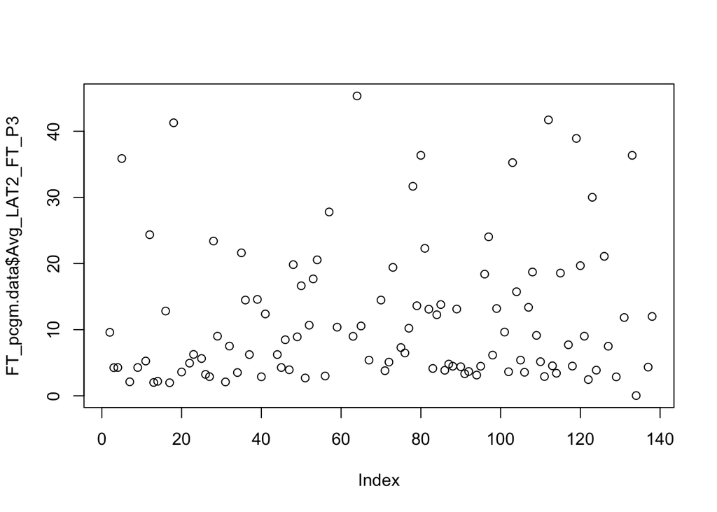

```r
#Complementary roles - Latency to success action 2

plot(FT_pcgm.data$Avg_LAT2_FT_P3)
```

```r
mean(FT_pcgm.data$Avg_LAT2_FT_P3, na.rm = TRUE)
```

```
## [1] 11.68505
```

```r
sd(FT_pcgm.data$Avg_LAT2_FT_P3, na.rm = TRUE)
```

```
## [1] 10.41208
```

```r
sum(!is.na(FT_pcgm.data$Avg_LAT2_FT_P3))
```

```
## [1] 107
```

## Secondary and Control Analyses

### Gender differences

#### Do parents of male and female infants have similar cooperative values?

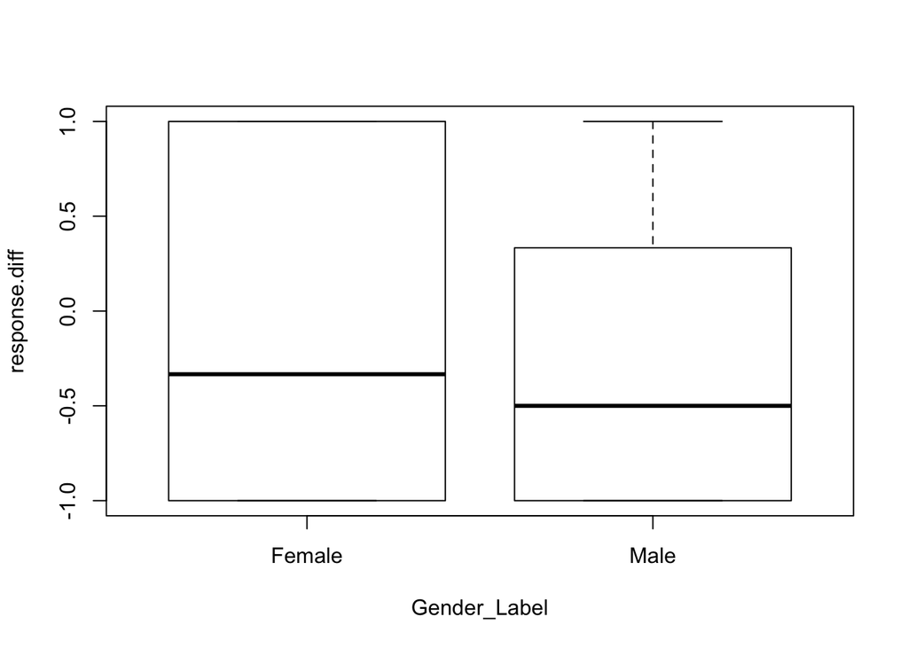

```r
with(P1.data_pcgm, boxplot(response.diff ~ Gender_Label))
```

```r
#As CVS is non-normally distributed nonparametric tests are utilized.
wilcox.test(response.diff ~ Gender, data = P1.data_pcgm)
```

```
##
##  Wilcoxon rank sum test with continuity correction
##
## data:  response.diff by Gender
## W = 5527.5, p-value = 0.4703
## alternative hypothesis: true location shift is not equal to 0
```

#### Are there gender differences for infant anticipation scores?

```r
wilcox.test(Avg_Anti_P3 ~ Gender, data = P1.data_pcgm, paired=FALSE)
```

```
##
##  Wilcoxon rank sum test with continuity correction
##
## data:  Avg_Anti_P3 by Gender
## W = 4342, p-value = 0.5733
## alternative hypothesis: true location shift is not equal to 0
```

#### Are there gender differences in infant cooperative ability in the parallel roles task?

```r
#test for gender differences in spatial coordination in the PRT
wilcox.test(Avg_SC_PR_P3 ~ Gender, data = PR_pcgm.data, conf.int = T, conf.level = .95, paired=FALSE, exact = FALSE)
```

```
##
##  Wilcoxon rank sum test with continuity correction
##
## data:  Avg_SC_PR_P3 by Gender
## W = 2647.5, p-value = 0.008363
## alternative hypothesis: true location shift is not equal to 0
## 95 percent confidence interval:
##  -0.00001433362 -0.00001945194
## sample estimates:
## difference in location
##         -0.00002031698
```

```r
Boys_PR<- PR_pcgm.data[which(PR_pcgm.data$Gender == 1),]
Girls_PR<- PR_pcgm.data[which(PR_pcgm.data$Gender == 2),]
median(Boys_PR$Avg_SC_PR_P3, na.rm = TRUE)
```

```
## [1] 4
```

```r
median(Girls_PR$Avg_SC_PR_P3, na.rm = TRUE)
```

```
## [1] 4
```

```r
#test for gender differences in success in the PRT
wilcox.test(Avg_Succ_PR_P3 ~ Gender, data = PR_pcgm.data, paired=FALSE)
```

```
##
##  Wilcoxon rank sum test with continuity correction
##
## data:  Avg_Succ_PR_P3 by Gender
## W = 3313.5, p-value = 0.8909
## alternative hypothesis: true location shift is not equal to 0
```

```r
#test for gender differences in latency to success in the PRT
t.test(Avg_Lat_PR_P3 ~ Gender, data = PR_pcgm.data, paired=FALSE)
```

```
##
##  Welch Two Sample t-test
##
## data:  Avg_Lat_PR_P3 by Gender
## t = -1.3798, df = 125.55, p-value = 0.1701
## alternative hypothesis: true difference in means is not equal to 0
## 95 percent confidence interval:
##  -7.526326  1.342849
## sample estimates:
## mean in group 1 mean in group 2
##        17.44598        20.53772
```

#### Are there gender differences in infant cooperative ability in the complementary roles task?

```r
#test for gender differences in spatial coordination in the CRT
wilcox.test(Avg_SC_FT_P3 ~ Gender, data = FT_pcgm.data)
```

```
##
##  Wilcoxon rank sum test with continuity correction
##
## data:  Avg_SC_FT_P3 by Gender
## W = 2302, p-value = 0.8351
## alternative hypothesis: true location shift is not equal to 0
```

```r
#test for gender differences in success in the CRT
wilcox.test(Avg_Succ_FT_P3 ~ Gender, data = FT_pcgm.data)
```

```
##
##  Wilcoxon rank sum test with continuity correction
##
## data:  Avg_Succ_FT_P3 by Gender
## W = 2270, p-value = 0.5959
## alternative hypothesis: true location shift is not equal to 0
```

```r
#test for gender differences for latency action 1 in the CRT
t.test(Avg_LAT1_FT_P3 ~ Gender, data = FT_pcgm.data)
```

```
##
##  Welch Two Sample t-test
##
## data:  Avg_LAT1_FT_P3 by Gender
## t = -0.25688, df = 133.87, p-value = 0.7977
## alternative hypothesis: true difference in means is not equal to 0
## 95 percent confidence interval:
##  -1.881719  1.449109
## sample estimates:
## mean in group 1 mean in group 2
##        5.905909        6.122214
```

```r
#test for gender differences for latency action 2 in the CRT
t.test(Avg_LAT2_FT_P3 ~ Gender, data = FT_pcgm.data)
```

```
##
##  Welch Two Sample t-test
##
## data:  Avg_LAT2_FT_P3 by Gender
## t = 0.072231, df = 104.88, p-value = 0.9426
## alternative hypothesis: true difference in means is not equal to 0
## 95 percent confidence interval:
##  -3.857592  4.149266
## sample estimates:
## mean in group 1 mean in group 2
##        11.76137        11.61554
```

### Age differences

#### Is age correlated with cooperative understanding?

```r
ag.cu.corr <- cor.test(x = PR_pcgm.data$Age_p3, y = PR_pcgm.data$Avg_Anti_P3, method = 'spearman')
ag.cu.corr
```

```
##
##  Spearman's rank correlation rho
##
## data:  PR_pcgm.data$Age_p3 and PR_pcgm.data$Avg_Anti_P3
## S = 637708, p-value = 0.7338
## alternative hypothesis: true rho is not equal to 0
## sample estimates:
##         rho
## -0.02753404
```

#### Is age correlated with cooperative ability in the parallel roles task?

```r
#is age related to spatial coordination in the PRT
ag.sc.pr.corr <- cor.test(x = PR_pcgm.data$Age_p3, y = PR_pcgm.data$Avg_SC_PR_P3, method = 'spearman')
ag.sc.pr.corr
```

```
##
##  Spearman's rank correlation rho
##
## data:  PR_pcgm.data$Age_p3 and PR_pcgm.data$Avg_SC_PR_P3
## S = 790081, p-value = 0.2294
## alternative hypothesis: true rho is not equal to 0
## sample estimates:
##         rho
## -0.09465245
```

```r
#is age related to success in the PRT
ag.succ.pr.corr <- cor.test(x = PR_pcgm.data$Age_p3, y = PR_pcgm.data$Avg_Succ_PR_P3, method = 'spearman')
ag.succ.pr.corr
```

```
##
##  Spearman's rank correlation rho
##
## data:  PR_pcgm.data$Age_p3 and PR_pcgm.data$Avg_Succ_PR_P3
## S = 678340, p-value = 0.4455
## alternative hypothesis: true rho is not equal to 0
## sample estimates:
##        rho
## 0.06016432
```

```r
#is age related to latency in the PRT
ag.lat.pr.corr <- cor.test(x = PR_pcgm.data$Age_p3, y = PR_pcgm.data$Avg_Lat_PR_P3, method = 'pearson')
ag.lat.pr.corr
```

```
##
##  Pearson's product-moment correlation
##
## data:  PR_pcgm.data$Age_p3 and PR_pcgm.data$Avg_Lat_PR_P3
## t = -0.51262, df = 129, p-value = 0.6091
## alternative hypothesis: true correlation is not equal to 0
## 95 percent confidence interval:
##  -0.2149511  0.1274230
## sample estimates:
##         cor
## -0.04508793
```

#### Is age correlated with cooperative ability in the complementary roles task?

```r
#is age related to spatial coordination in the CRT
ag.sc.ft.corr <- cor.test(x = FT_pcgm.data$Age_p3, y = FT_pcgm.data$Avg_SC_FT_P3, method = 'spearman')
ag.sc.ft.corr
```

```
##
##  Spearman's rank correlation rho
##
## data:  FT_pcgm.data$Age_p3 and FT_pcgm.data$Avg_SC_FT_P3
## S = 407908, p-value = 0.7552
## alternative hypothesis: true rho is not equal to 0
## sample estimates:
##        rho
## 0.02698363
```

```r
#is age related to success in the CRT
ag.succ.ft.corr <- cor.test(x = FT_pcgm.data$Age_p3, y = FT_pcgm.data$Avg_Succ_FT_P3, method = 'spearman')
ag.succ.ft.corr
```

```
##
##  Spearman's rank correlation rho
##
## data:  FT_pcgm.data$Age_p3 and FT_pcgm.data$Avg_Succ_FT_P3
## S = 420784, p-value = 0.8338
## alternative hypothesis: true rho is not equal to 0
## sample estimates:
##        rho
## 0.01808976
```

```r
#is age related to latency to success action 1 in the CRT
ag.lat1.ft.corr <- cor.test(x = FT_pcgm.data$Age_p3, y = FT_pcgm.data$Avg_LAT1_FT_P3, method = 'pearson')
ag.lat1.ft.corr
```

```
##
##  Pearson's product-moment correlation
##
## data:  FT_pcgm.data$Age_p3 and FT_pcgm.data$Avg_LAT1_FT_P3
## t = -1.2155, df = 133, p-value = 0.2263
## alternative hypothesis: true correlation is not equal to 0
## 95 percent confidence interval:
##  -0.26900657  0.06530029
## sample estimates:
##        cor
## -0.1048133
```

```r
#is age related to latency to success action 1 in the CRT
ag.lat2.ft.corr <- cor.test(x = FT_pcgm.data$Age_p3, y = FT_pcgm.data$Avg_LAT2_FT_P3, method = 'pearson')
ag.lat2.ft.corr
```

```
##
##  Pearson's product-moment correlation
##
## data:  FT_pcgm.data$Age_p3 and FT_pcgm.data$Avg_LAT2_FT_P3
## t = -2.8317, df = 104, p-value = 0.00556
## alternative hypothesis: true correlation is not equal to 0
## 95 percent confidence interval:
##  -0.4360517 -0.0809257
## sample estimates:
##        cor
## -0.2675509
```

#### Does at home experience shape infants cooperative competence?

```r
### Cooperative Understanding ###
#Check for relationship between at home experience and infant cooperative understanding
sg.cu.corr <- cor.test(x = P1.data_pcgm$Pi_social_games_freq_p1_fixed, y = P1.data_pcgm$Avg_Anti_P3, method = 'spearman')
sg.cu.corr
```

```
##
##  Spearman's rank correlation rho
##
## data:  P1.data_pcgm$Pi_social_games_freq_p1_fixed and P1.data_pcgm$Avg_Anti_P3
## S = 835595, p-value = 0.3258
## alternative hypothesis: true rho is not equal to 0
## sample estimates:
##         rho
## -0.07649845
```

```r
#### Cooperative Ability ###

#PR social games and spatial coordination
sg.sc.pr.corr <- cor.test(x = PR_pcgm.data$Pi_social_games_freq_p1_fixed, y = PR_pcgm.data$Avg_SC_PR_P3, method = 'spearman')
sg.sc.pr.corr
```

```
##
##  Spearman's rank correlation rho
##
## data:  PR_pcgm.data$Pi_social_games_freq_p1_fixed and PR_pcgm.data$Avg_SC_PR_P3
## S = 499596, p-value = 0.1135
## alternative hypothesis: true rho is not equal to 0
## sample estimates:
##       rho
## 0.1293202
```

```r
#PR social games and success
sg.succ.pr.corr <- cor.test(x = PR_pcgm.data$Pi_social_games_freq_p1_fixed, y = PR_pcgm.data$Avg_Succ_PR_P3, method = 'spearman')
sg.succ.pr.corr
```

```
##
##  Spearman's rank correlation rho
##
## data:  PR_pcgm.data$Pi_social_games_freq_p1_fixed and PR_pcgm.data$Avg_Succ_PR_P3
## S = 602847, p-value = 0.5371
## alternative hypothesis: true rho is not equal to 0
## sample estimates:
##         rho
## -0.05062192
```

```r
#PR social games and latency to success
sg.lat.pr.corr <- cor.test(x = PR_pcgm.data$Pi_social_games_freq_p1_fixed, y = PR_pcgm.data$Avg_Lat_PR_P3, method = 'spearman')
sg.lat.pr.corr
```

```
##
##  Spearman's rank correlation rho
##
## data:  PR_pcgm.data$Pi_social_games_freq_p1_fixed and PR_pcgm.data$Avg_Lat_PR_P3
## S = 313733, p-value = 0.688
## alternative hypothesis: true rho is not equal to 0
## sample estimates:
##         rho
## -0.03671976
```

```r
#CR social games and spatial coordination
sg.sc.ft.corr <- cor.test(x = FT_pcgm.data$Pi_social_games_freq_p1_fixed, y = FT_pcgm.data$Avg_SC_FT_P3, method = 'spearman')
sg.sc.ft.corr
```

```
##
##  Spearman's rank correlation rho
##
## data:  FT_pcgm.data$Pi_social_games_freq_p1_fixed and FT_pcgm.data$Avg_SC_FT_P3
## S = 342201, p-value = 0.8149
## alternative hypothesis: true rho is not equal to 0
## sample estimates:
##        rho
## 0.02089573
```

```r
#CR social games and success
sg.succ.ft.corr <- cor.test(x = FT_pcgm.data$Pi_social_games_freq_p1_fixed, y = FT_pcgm.data$Avg_Succ_FT_P3, method = 'spearman')
sg.succ.ft.corr
```

```
##
##  Spearman's rank correlation rho
##
## data:  FT_pcgm.data$Pi_social_games_freq_p1_fixed and FT_pcgm.data$Avg_Succ_FT_P3
## S = 354959, p-value = 0.9298
## alternative hypothesis: true rho is not equal to 0
## sample estimates:
##         rho
## 0.007829884
```

```r
#CR social games and latency toy retrieval
sg.lat1.ft.corr <- cor.test(x = FT_pcgm.data$Pi_social_games_freq_p1_fixed, y = FT_pcgm.data$Avg_LAT1_FT_P3, method = 'spearman')
sg.lat1.ft.corr
```

```
##
##  Spearman's rank correlation rho
##
## data:  FT_pcgm.data$Pi_social_games_freq_p1_fixed and FT_pcgm.data$Avg_LAT1_FT_P3
## S = 367646, p-value = 0.3898
## alternative hypothesis: true rho is not equal to 0
## sample estimates:
##         rho
## -0.07695193
```

```r
#CR social games and latency goal completion
sg.lat2.ft.corr <- cor.test(x = FT_pcgm.data$Pi_social_games_freq_p1_fixed, y = FT_pcgm.data$Avg_LAT2_FT_P3, method = 'spearman')
sg.lat2.ft.corr
```

```
##
##  Spearman's rank correlation rho
##
## data:  FT_pcgm.data$Pi_social_games_freq_p1_fixed and FT_pcgm.data$Avg_LAT2_FT_P3
## S = 161689, p-value = 0.9995
## alternative hypothesis: true rho is not equal to 0
## sample estimates:
##           rho
## 0.00006962133
```

## Focal Analyses

### Study 1

#### Do parents who value cooperation for more altruistic reasons play more social games with their infant?

```r
resp_sg_pcgm.corr <- cor.test(x = P1.data_pcgm$Pi_social_games_freq_p1_fixed, y = P1.data_pcgm$response.diff, method = 'spearman')
resp_sg_pcgm.corr
```

```
##
##  Spearman's rank correlation rho
##
## data:  P1.data_pcgm$Pi_social_games_freq_p1_fixed and P1.data_pcgm$response.diff
## S = 1378104, p-value = 0.797
## alternative hypothesis: true rho is not equal to 0
## sample estimates:
##         rho
## -0.01825357
```

#### Are there associations between parents’ personality (FFM) and cooperative values?

```r
#Agreeableness Personality and Cooperative Value Score (CVS) #.ns
resp_agree.corr <- cor.test(x = personality.values.df_pcgm$response.diff, y = personality.values.df_pcgm$Agree, method = 'spearman')
resp_agree.corr
```

```
##
##  Spearman's rank correlation rho
##
## data:  personality.values.df_pcgm$response.diff and personality.values.df_pcgm$Agree
## S = 410904, p-value = 0.3376
## alternative hypothesis: true rho is not equal to 0
## sample estimates:
##        rho
## 0.08194283
```

```r
#Openness Personality and Cooperative Value Score (CVS) #.ns
resp_open.corr <- cor.test(x = personality.values.df_pcgm$response.diff, y = personality.values.df_pcgm$Open, method = 'spearman')
resp_open.corr
```

```
##
##  Spearman's rank correlation rho
##
## data:  personality.values.df_pcgm$response.diff and personality.values.df_pcgm$Open
## S = 373417, p-value = 0.08442
## alternative hypothesis: true rho is not equal to 0
## sample estimates:
##       rho
## 0.1474284
```

```r
#Conscienciousness Personality and Cooperative Value Score (CVS) #.ns
resp_cons.corr <- cor.test(x = personality.values.df_pcgm$response.diff, y = personality.values.df_pcgm$Cons, method = 'spearman')
resp_cons.corr
```

```
##
##  Spearman's rank correlation rho
##
## data:  personality.values.df_pcgm$response.diff and personality.values.df_pcgm$Cons
## S = 432153, p-value = 0.8767
## alternative hypothesis: true rho is not equal to 0
## sample estimates:
##        rho
## 0.01332474
```

```r
#Extraversion Personality and Cooperative Value Score (CVS) #.ns

resp_extra.corr <- cor.test(x = personality.values.df_pcgm$response.diff, y = personality.values.df_pcgm$Extra, method = 'spearman')
resp_extra.corr
```

```
##
##  Spearman's rank correlation rho
##
## data:  personality.values.df_pcgm$response.diff and personality.values.df_pcgm$Extra
## S = 437029, p-value = 0.9796
## alternative hypothesis: true rho is not equal to 0
## sample estimates:
##         rho
## 0.002192268
```

```r
#Neuroticism Personality and Cooperative Value Score (CVS) #.ns
resp_neur.corr <- cor.test(x = personality.values.df_pcgm$response.diff, y = personality.values.df_pcgm$Neur, method = 'spearman')
resp_neur.corr
```

```
##
##  Spearman's rank correlation rho
##
## data:  personality.values.df_pcgm$response.diff and personality.values.df_pcgm$Neur
## S = 453122, p-value = 0.7232
## alternative hypothesis: true rho is not equal to 0
## sample estimates:
##        rho
## 0.03009214
```

#### Are there associations between parents’ personality (FFM) and cooperative experience provided to their infant?

```r
#Agreeableness Personality and Social Games (SG)
sg.resp_agree.corr <- cor.test(x = personality.values.df_pcgm$Pi_social_games_freq_p1_fixed, y = personality.values.df_pcgm$Agree, method = 'pearson')
sg.resp_agree.corr
```

```
##
##  Pearson's product-moment correlation
##
## data:  personality.values.df_pcgm$Pi_social_games_freq_p1_fixed and personality.values.df_pcgm$Agree
## t = 1.6698, df = 131, p-value = 0.09735
## alternative hypothesis: true correlation is not equal to 0
## 95 percent confidence interval:
##  -0.02651613  0.30704368
## sample estimates:
##       cor
## 0.1443623
```

```r
#Openness Personality and Social Games (SG)
sg.resp_open.corr <- cor.test(x = personality.values.df_pcgm$Pi_social_games_freq_p1_fixed, y = personality.values.df_pcgm$Open, method = 'pearson')
sg.resp_open.corr
```

```
##
##  Pearson's product-moment correlation
##
## data:  personality.values.df_pcgm$Pi_social_games_freq_p1_fixed and personality.values.df_pcgm$Open
## t = -0.12243, df = 130, p-value = 0.9027
## alternative hypothesis: true correlation is not equal to 0
## 95 percent confidence interval:
##  -0.1812772  0.1604295
## sample estimates:
##        cor
## -0.0107373
```

```r
#Conscienciousness Personality and Social Games (SG)
sg.resp_cons.corr <- cor.test(x = personality.values.df_pcgm$Pi_social_games_freq_p1_fixed, y = personality.values.df_pcgm$Cons, method = 'pearson')
sg.resp_cons.corr
```

```
##
##  Pearson's product-moment correlation
##
## data:  personality.values.df_pcgm$Pi_social_games_freq_p1_fixed and personality.values.df_pcgm$Cons
## t = -0.92667, df = 130, p-value = 0.3558
## alternative hypothesis: true correlation is not equal to 0
## 95 percent confidence interval:
##  -0.24844058  0.09112679
## sample estimates:
##         cor
## -0.08100702
```

```r
#Extraversion Personality and Social Games (SG)
sg.resp_extra.corr <- cor.test(x = personality.values.df_pcgm$Pi_social_games_freq_p1_fixed, y = personality.values.df_pcgm$Extra, method = 'pearson')
sg.resp_extra.corr
```

```
##
##  Pearson's product-moment correlation
##
## data:  personality.values.df_pcgm$Pi_social_games_freq_p1_fixed and personality.values.df_pcgm$Extra
## t = 1.1801, df = 130, p-value = 0.2401
## alternative hypothesis: true correlation is not equal to 0
## 95 percent confidence interval:
##  -0.06914088  0.26908677
## sample estimates:
##       cor
## 0.1029478
```

```r
#Neuroticism Personality and Social Games (SG)
sg.resp_neur.corr <- cor.test(x = personality.values.df_pcgm$Pi_social_games_freq_p1_fixed, y = personality.values.df_pcgm$Neur, method = 'pearson')
sg.resp_neur.corr
```

```
##
##  Pearson's product-moment correlation
##
## data:  personality.values.df_pcgm$Pi_social_games_freq_p1_fixed and personality.values.df_pcgm$Neur
## t = 1.4903, df = 133, p-value = 0.1385
## alternative hypothesis: true correlation is not equal to 0
## 95 percent confidence interval:
##  -0.04169635  0.29082330
## sample estimates:
##       cor
## 0.1281637
```

#### Are there associations between parent CVS and infant cooperative understanding?

```r
cu_cvs.corr <- cor.test(x = P1.data_pcgm$response.diff, y = P1.data_pcgm$Avg_Anti_P3, method = 'spearman')
cu_cvs.corr
```

```
##
##  Spearman's rank correlation rho
##
## data:  P1.data_pcgm$response.diff and P1.data_pcgm$Avg_Anti_P3
## S = 863421, p-value = 0.8281
## alternative hypothesis: true rho is not equal to 0
## sample estimates:
##        rho
## 0.01657712
```

#### Are there associations between parent personality (FFM) and infant cooperative understanding? *YES*

```r
CU_pp.model.pcgm <- lm(Avg_Anti_P3 ~ Agree + Open + Cons + Extra + Neur, data = personality.df_pcgm)
CU_pp.model.pcgm
```

```
##
## Call:
## lm(formula = Avg_Anti_P3 ~ Agree + Open + Cons + Extra + Neur,
##     data = personality.df_pcgm)
##
## Coefficients:
## (Intercept)        Agree         Open         Cons        Extra         Neur
##   -0.079893     0.008455     0.019216     0.077252    -0.050516     0.019888
```

```r
summary(CU_pp.model.pcgm)
```

```
##
## Call:
## lm(formula = Avg_Anti_P3 ~ Agree + Open + Cons + Extra + Neur,
##     data = personality.df_pcgm)
##
## Residuals:
##      Min       1Q   Median       3Q      Max
## -0.38612 -0.25137 -0.05891  0.20266  0.74278
##
## Coefficients:
##              Estimate Std. Error t value Pr(>|t|)
## (Intercept) -0.079893   0.436795  -0.183   0.8552
## Agree        0.008455   0.050194   0.168   0.8665
## Open         0.019216   0.038328   0.501   0.6170
## Cons         0.077252   0.038413   2.011   0.0465 *
## Extra       -0.050516   0.030984  -1.630   0.1056
## Neur         0.019888   0.031767   0.626   0.5324
## ---
## Signif. codes:  0 '***' 0.001 '**' 0.01 '*' 0.05 '.' 0.1 ' ' 1
##
## Residual standard error: 0.2909 on 123 degrees of freedom
##   (63 observations deleted due to missingness)
## Multiple R-squared:  0.04644,    Adjusted R-squared:  0.007675
## F-statistic: 1.198 on 5 and 123 DF,  p-value: 0.3141
```

#### Does parent CVS predict infant cooperative ability in the parallel roles task?

```r
#Parallel roles - Spatial Coordination - Ordinal regression

PR_pcgm.data$Avg_SC_PR_P3_cat <- factor(PR_pcgm.data$Avg_SC_PR_P3, ordered = TRUE)
PR_sc.cvs.OR_model <- polr(Avg_SC_PR_P3_cat ~ response.diff + Gender, data = PR_pcgm.data, Hess=TRUE)
summary(PR_sc.cvs.OR_model)
```

```
## Call:
## polr(formula = Avg_SC_PR_P3_cat ~ response.diff + Gender, data = PR_pcgm.data,
##     Hess = TRUE)
##
## Coefficients:
##                Value Std. Error t value
## response.diff 0.2233     0.1940   1.151
## Gender        0.8375     0.3287   2.548
##
## Intercepts:
##       Value   Std. Error t value
## 1|1.5 -3.2686  0.8406    -3.8886
## 1.5|2 -2.8576  0.7347    -3.8894
## 2|2.5 -1.2401  0.5290    -2.3442
## 2.5|3 -1.0220  0.5177    -1.9743
## 3|3.5 -0.2654  0.4933    -0.5381
## 3.5|4  0.3219  0.4882     0.6593
## 4|4.5  3.4883  0.5932     5.8803
## 4.5|5  6.3304  1.1396     5.5547
##
## Residual Deviance: 421.6718
## AIC: 441.6718
## (13 observations deleted due to missingness)
```

```r
PR_SC.model.table <- coef(summary(PR_sc.cvs.OR_model))
PR_SC.model.table
```

```
##                    Value Std. Error    t value
## response.diff  0.2232975  0.1939938  1.1510547
## Gender         0.8375298  0.3286786  2.5481722
## 1|1.5         -3.2685830  0.8405507 -3.8886211
## 1.5|2         -2.8575749  0.7347082 -3.8894011
## 2|2.5         -1.2400615  0.5289857 -2.3442252
## 2.5|3         -1.0220383  0.5176666 -1.9743175
## 3|3.5         -0.2654081  0.4932732 -0.5380549
## 3.5|4          0.3219057  0.4882187  0.6593473
## 4|4.5          3.4883140  0.5932241  5.8802631
## 4.5|5          6.3303578  1.1396464  5.5546682
```

```r
#P values and other add to table
p <- pnorm(abs(PR_SC.model.table[, "t value"]), lower.tail = FALSE) * 2
PR_SC.model.table <- cbind(PR_SC.model.table, "p value" = p)
PR_SC.model.table
```

```
##                    Value Std. Error    t value           p value
## response.diff  0.2232975  0.1939938  1.1510547 0.249709731577574
## Gender         0.8375298  0.3286786  2.5481722 0.010828899110179
## 1|1.5         -3.2685830  0.8405507 -3.8886211 0.000100815346725
## 1.5|2         -2.8575749  0.7347082 -3.8894011 0.000100491922089
## 2|2.5         -1.2400615  0.5289857 -2.3442252 0.019066657176234
## 2.5|3         -1.0220383  0.5176666 -1.9743175 0.048345654419832
## 3|3.5         -0.2654081  0.4932732 -0.5380549 0.590539156009219
## 3.5|4          0.3219057  0.4882187  0.6593473 0.509672774389657
## 4|4.5          3.4883140  0.5932241  5.8802631 0.000000004096148
## 4.5|5          6.3303578  1.1396464  5.5546682 0.000000027813964
```

```r
#confidence intervals
ci <- confint(PR_sc.cvs.OR_model)
ci
```

```
##                    2.5 %    97.5 %
## response.diff -0.1543137 0.6081918
## Gender         0.2033489 1.4960765
```

```r
exp(ci)
```

```
##                   2.5 %   97.5 %
## response.diff 0.8570031 1.837106
## Gender        1.2254999 4.464140
```

```r
#odds ratio
exp(coef(PR_sc.cvs.OR_model))
```

```
## response.diff        Gender
##      1.250192      2.310652
```

```r
#Parallel roles - Success - Ordinal Regression

PR_pcgm.data$Avg_Succ_PR_P3_cat <- factor(PR_pcgm.data$Avg_Succ_PR_P3, ordered = TRUE)

PR_succ.cvs.OR_model <- polr(Avg_Succ_PR_P3_cat ~ response.diff, data = PR_pcgm.data, Hess=TRUE)
summary(PR_succ.cvs.OR_model)
```

```
## Call:
## polr(formula = Avg_Succ_PR_P3_cat ~ response.diff, data = PR_pcgm.data,
##     Hess = TRUE)
##
## Coefficients:
##                Value Std. Error t value
## response.diff 0.3528     0.1815   1.944
##
## Intercepts:
##       Value   Std. Error t value
## 0|0.5 -1.5649  0.2164    -7.2313
## 0.5|1 -0.9350  0.1874    -4.9906
## 1|1.5 -0.3762  0.1747    -2.1532
## 1.5|2  0.3393  0.1741     1.9485
##
## Residual Deviance: 464.248
## AIC: 474.248
## (13 observations deleted due to missingness)
```

```r
PR_Succ.model.table <- coef(summary(PR_succ.cvs.OR_model))
PR_Succ.model.table
```

```
##                    Value Std. Error   t value
## response.diff  0.3527864  0.1814776  1.943966
## 0|0.5         -1.5648561  0.2163996 -7.231326
## 0.5|1         -0.9350330  0.1873575 -4.990636
## 1|1.5         -0.3761590  0.1747006 -2.153164
## 1.5|2          0.3392588  0.1741102  1.948529
```

```r
#P values and other add to table
p <- pnorm(abs(PR_Succ.model.table[, "t value"]), lower.tail = FALSE) * 2
PR_Succ.model.table <- cbind(PR_Succ.model.table, "p value" = p)
PR_Succ.model.table
```

```
##                    Value Std. Error   t value               p value
## response.diff  0.3527864  0.1814776  1.943966 0.0518995443112697449
## 0|0.5         -1.5648561  0.2163996 -7.231326 0.0000000000004783003
## 0.5|1         -0.9350330  0.1873575 -4.990636 0.0000006018091169370
## 1|1.5         -0.3761590  0.1747006 -2.153164 0.0313057762721466112
## 1.5|2          0.3392588  0.1741102  1.948529 0.0513516831082534916
```

```r
#confidence intervals
ci <- confint(PR_succ.cvs.OR_model)
exp(ci)
```

```
##    2.5 %   97.5 %
## 1.000427 2.041460
```

```r
#odds ratio
exp(coef(PR_succ.cvs.OR_model))
```

```
## response.diff
##      1.423027
```

```r
#Parallel roles - Latency to success - Linear regression
PR_Lat.model_pcgm <- lm(Avg_Lat_PR_P3 ~ response.diff, data = PR_pcgm.data)
PR_Lat.model_pcgm
```

```
##
## Call:
## lm(formula = Avg_Lat_PR_P3 ~ response.diff, data = PR_pcgm.data)
##
## Coefficients:
##   (Intercept)  response.diff
##       19.1642         0.3476
```

```r
summary(PR_Lat.model_pcgm)
```

```
##
## Call:
## lm(formula = Avg_Lat_PR_P3 ~ response.diff, data = PR_pcgm.data)
##
## Residuals:
##     Min      1Q  Median      3Q     Max
## -19.124  -8.704  -2.207   4.747  46.436
##
## Coefficients:
##               Estimate Std. Error t value            Pr(>|t|)
## (Intercept)    19.1642     1.2064   15.89 <0.0000000000000002 ***
## response.diff   0.3476     1.3915    0.25               0.803
## ---
## Signif. codes:  0 '***' 0.001 '**' 0.01 '*' 0.05 '.' 0.1 ' ' 1
##
## Residual standard error: 12.95 on 124 degrees of freedom
##   (43 observations deleted due to missingness)
## Multiple R-squared:  0.000503,   Adjusted R-squared:  -0.007558
## F-statistic: 0.0624 on 1 and 124 DF,  p-value: 0.8032
```

#### Does parent CVS predict infant cooperative ability in the complementary roles task?

```r
#Complementary Roles - Spatial Coordination -  Ordinal Regression

FT_pcgm.data$Avg_SC_FT_P3_cat <- factor(FT_pcgm.data$Avg_SC_FT_P3, ordered = TRUE)
FT_sc.cvs.OR_model <- polr(Avg_SC_FT_P3_cat ~ response.diff, data = FT_pcgm.data, Hess=TRUE)
summary(FT_sc.cvs.OR_model)
```

```
## Call:
## polr(formula = Avg_SC_FT_P3_cat ~ response.diff, data = FT_pcgm.data,
##     Hess = TRUE)
##
## Coefficients:
##                Value Std. Error t value
## response.diff 0.4659     0.2084   2.235
##
## Intercepts:
##       Value   Std. Error t value
## 2|2.5 -1.6476  0.2449    -6.7281
## 2.5|3 -1.5452  0.2381    -6.4887
## 3|3.5 -0.5505  0.1945    -2.8297
## 3.5|4 -0.5166  0.1937    -2.6667
## 4|4.5  3.4022  0.5089     6.6856
##
## Residual Deviance: 294.8867
## AIC: 306.8867
## (9 observations deleted due to missingness)
```

```r
FT_SC.model.table <- coef(summary(FT_sc.cvs.OR_model))
FT_SC.model.table
```

```
##                    Value Std. Error   t value
## response.diff  0.4659467  0.2084394  2.235406
## 2|2.5         -1.6476020  0.2448828 -6.728125
## 2.5|3         -1.5451838  0.2381357 -6.488669
## 3|3.5         -0.5504822  0.1945353 -2.829729
## 3.5|4         -0.5166205  0.1937312 -2.666687
## 4|4.5          3.4021756  0.5088810  6.685601
```

```r
#P values and other add to table
p <- pnorm(abs(FT_SC.model.table[, "t value"]), lower.tail = FALSE) * 2
FT_SC.model.table <- cbind(FT_SC.model.table, "p value" = p)
FT_SC.model.table
```

```
##                    Value Std. Error   t value             p value
## response.diff  0.4659467  0.2084394  2.235406 0.02539068488329952
## 2|2.5         -1.6476020  0.2448828 -6.728125 0.00000000001718638
## 2.5|3         -1.5451838  0.2381357 -6.488669 0.00000000008659774
## 3|3.5         -0.5504822  0.1945353 -2.829729 0.00465874224360623
## 3.5|4         -0.5166205  0.1937312 -2.666687 0.00766030721111358
## 4|4.5          3.4021756  0.5088810  6.685601 0.00000000002299785
```

```r
#confidence intervals
ci <- confint(FT_sc.cvs.OR_model)
exp(ci)
```

```
##    2.5 %   97.5 %
## 1.065955 2.421099
```

```r
#odds ratio
exp(coef(FT_sc.cvs.OR_model))
```

```
## response.diff
##      1.593522
```

```r
#Complementary Roles - Success Ordinal - Regression

FT_pcgm.data$Avg_Succ_FT_P3_cat <- factor(FT_pcgm.data$Avg_Succ_FT_P3, ordered = TRUE)
FT_succ.cvs.OR_model <- polr(Avg_Succ_FT_P3_cat ~ response.diff, data = FT_pcgm.data, Hess=TRUE)
summary(FT_succ.cvs.OR_model)
```

```
## Call:
## polr(formula = Avg_Succ_FT_P3_cat ~ response.diff, data = FT_pcgm.data,
##     Hess = TRUE)
##
## Coefficients:
##                Value Std. Error t value
## response.diff 0.5822     0.2206   2.639
##
## Intercepts:
##       Value   Std. Error t value
## 1|1.5 -1.5161  0.2390    -6.3429
## 1.5|2 -0.5543  0.2010    -2.7576
##
## Residual Deviance: 241.5714
## AIC: 247.5714
## (8 observations deleted due to missingness)
```

```r
FT_Succ.model.table <- coef(summary(FT_succ.cvs.OR_model))
FT_Succ.model.table
```

```
##                    Value Std. Error   t value
## response.diff  0.5821507  0.2205751  2.639240
## 1|1.5         -1.5160784  0.2390192 -6.342915
## 1.5|2         -0.5543221  0.2010126 -2.757648
```

```r
#P values and other add to table
p <- pnorm(abs(FT_Succ.model.table[, "t value"]), lower.tail = FALSE) * 2
FT_Succ.model.table <- cbind(FT_Succ.model.table, "p value" = p)
FT_Succ.model.table
```

```
##                    Value Std. Error   t value            p value
## response.diff  0.5821507  0.2205751  2.639240 0.0083092142606167
## 1|1.5         -1.5160784  0.2390192 -6.342915 0.0000000002254571
## 1.5|2         -0.5543221  0.2010126 -2.757648 0.0058218797535311
```

```r
#confidence intervals
ci <- confint(FT_succ.cvs.OR_model, level = 0.95)
exp(ci)
```

```
##    2.5 %   97.5 %
## 1.175636 2.804885
```

```r
#odds ratio
exp(coef(FT_succ.cvs.OR_model))
```

```
## response.diff
##      1.789884
```

```r
#Complementary Roles - Latency Action 1 - Linear regression
FT_Lat1.model_pcgm <- lm(Avg_LAT1_FT_P3 ~ response.diff, data = FT_pcgm.data)
FT_Lat1.model_pcgm
```

```
##
## Call:
## lm(formula = Avg_LAT1_FT_P3 ~ response.diff, data = FT_pcgm.data)
##
## Coefficients:
##   (Intercept)  response.diff
##         6.267          1.108
```

```r
summary(FT_Lat1.model_pcgm)
```

```
##
## Call:
## lm(formula = Avg_LAT1_FT_P3 ~ response.diff, data = FT_pcgm.data)
##
## Residuals:
##    Min     1Q Median     3Q    Max
## -5.574 -3.094 -1.596  1.256 14.241
##
## Coefficients:
##               Estimate Std. Error t value            Pr(>|t|)
## (Intercept)     6.2667     0.4345   14.42 <0.0000000000000002 ***
## response.diff   1.1075     0.4878    2.27              0.0249 *
## ---
## Signif. codes:  0 '***' 0.001 '**' 0.01 '*' 0.05 '.' 0.1 ' ' 1
##
## Residual standard error: 4.655 on 126 degrees of freedom
##   (10 observations deleted due to missingness)
## Multiple R-squared:  0.0393, Adjusted R-squared:  0.03168
## F-statistic: 5.155 on 1 and 126 DF,  p-value: 0.02488
```

```r
confint(FT_Lat1.model_pcgm, level = .95)
```

```
##                  2.5 %   97.5 %
## (Intercept)   5.406787 7.126661
## response.diff 0.142141 2.072881
```

```r
#Complementary Roles - Latency Action 2 - Linear regression
FT_Lat2.model_pcgm <- lm(Avg_LAT2_FT_P3 ~ response.diff + Age_p3, data = FT_pcgm.data)
FT_Lat2.model_pcgm
```

```
##
## Call:
## lm(formula = Avg_LAT2_FT_P3 ~ response.diff + Age_p3, data = FT_pcgm.data)
##
## Coefficients:
##   (Intercept)  response.diff         Age_p3
##        76.366          2.640         -4.494
```

```r
summary(FT_Lat2.model_pcgm)
```

```
##
## Call:
## lm(formula = Avg_LAT2_FT_P3 ~ response.diff + Age_p3, data = FT_pcgm.data)
##
## Residuals:
##     Min      1Q  Median      3Q     Max
## -15.521  -6.449  -3.425   4.896  30.165
##
## Coefficients:
##               Estimate Std. Error t value Pr(>|t|)
## (Intercept)     76.366     23.863   3.200  0.00186 **
## response.diff    2.640      1.167   2.262  0.02593 *
## Age_p3          -4.494      1.676  -2.681  0.00863 **
## ---
## Signif. codes:  0 '***' 0.001 '**' 0.01 '*' 0.05 '.' 0.1 ' ' 1
##
## Residual standard error: 10.07 on 97 degrees of freedom
##   (38 observations deleted due to missingness)
## Multiple R-squared:  0.1183, Adjusted R-squared:  0.1001
## F-statistic: 6.506 on 2 and 97 DF,  p-value: 0.002232
```

```r
confint(FT_Lat2.model_pcgm, level = .95)
```

```
##                    2.5 %     97.5 %
## (Intercept)   29.0051225 123.727478
## response.diff  0.3235766   4.956899
## Age_p3        -7.8204352  -1.166666
```

#### Does parent personality (FFM) predict infant cooperative ability on the parallel roles task?

```r
#Parallel roles task - Spatial coordination - Ordinal regression
PR_pcgm.data.p3.p5$Avg_SC_PR_P3_cat <- factor(PR_pcgm.data.p3.p5$Avg_SC_PR_P3, ordered = TRUE)
PR_sc.big5.OR_model <- polr(Avg_SC_PR_P3_cat ~ Agree + Open + Cons + Extra + Neur + Gender, data = PR_pcgm.data.p3.p5, Hess=TRUE)
summary(PR_sc.big5.OR_model)
```

```
## Call:
## polr(formula = Avg_SC_PR_P3_cat ~ Agree + Open + Cons + Extra +
##     Neur + Gender, data = PR_pcgm.data.p3.p5, Hess = TRUE)
##
## Coefficients:
##          Value Std. Error t value
## Agree   0.9931     0.3683  2.6960
## Open    0.0743     0.2894  0.2567
## Cons   -0.2122     0.3021 -0.7026
## Extra   0.1260     0.2512  0.5015
## Neur   -0.5662     0.2463 -2.2988
## Gender  0.3460     0.3878  0.8921
##
## Intercepts:
##       Value   Std. Error t value
## 1|1.5 -0.6960  3.5478    -0.1962
## 1.5|2  0.0121  3.4779     0.0035
## 2|2.5  1.6625  3.4315     0.4845
## 2.5|3  1.7899  3.4313     0.5216
## 3|3.5  2.7217  3.4332     0.7928
## 3.5|4  3.4520  3.4403     1.0034
## 4|4.5  6.9823  3.4934     1.9987
## 4.5|5  9.2900  3.6232     2.5640
##
## Residual Deviance: 282.1092
## AIC: 310.1092
## (36 observations deleted due to missingness)
```

```r
PR_SC_5.model.table <- coef(summary(PR_sc.big5.OR_model))
PR_SC_5.model.table
```

```
##              Value Std. Error      t value
## Agree   0.99306194  0.3683466  2.695998525
## Open    0.07429757  0.2894412  0.256693191
## Cons   -0.21222758  0.3020561 -0.702609847
## Extra   0.12599745  0.2512219  0.501538463
## Neur   -0.56619931  0.2463061 -2.298763278
## Gender  0.34597125  0.3878208  0.892090598
## 1|1.5  -0.69600313  3.5478187 -0.196177759
## 1.5|2   0.01211526  3.4779442  0.003483455
## 2|2.5   1.66247824  3.4315187  0.484473021
## 2.5|3   1.78989512  3.4312897  0.521639175
## 3|3.5   2.72171347  3.4332428  0.792752986
## 3.5|4   3.45197200  3.4403264  1.003385041
## 4|4.5   6.98226627  3.4934343  1.998682591
## 4.5|5   9.29003118  3.6232422  2.564010562
```

```r
#P values and other add to table
p <- pnorm(abs(PR_SC_5.model.table[, "t value"]), lower.tail = FALSE) * 2
PR_SC_5.model.table <- cbind(PR_SC_5.model.table, "p value" = p)
PR_SC_5.model.table
```

```
##              Value Std. Error      t value     p value
## Agree   0.99306194  0.3683466  2.695998525 0.007017798
## Open    0.07429757  0.2894412  0.256693191 0.797415628
## Cons   -0.21222758  0.3020561 -0.702609847 0.482298924
## Extra   0.12599745  0.2512219  0.501538463 0.615992216
## Neur   -0.56619931  0.2463061 -2.298763278 0.021518385
## Gender  0.34597125  0.3878208  0.892090598 0.372344374
## 1|1.5  -0.69600313  3.5478187 -0.196177759 0.844471035
## 1.5|2   0.01211526  3.4779442  0.003483455 0.997220610
## 2|2.5   1.66247824  3.4315187  0.484473021 0.628050207
## 2.5|3   1.78989512  3.4312897  0.521639175 0.601921582
## 3|3.5   2.72171347  3.4332428  0.792752986 0.427921753
## 3.5|4   3.45197200  3.4403264  1.003385041 0.315675119
## 4|4.5   6.98226627  3.4934343  1.998682591 0.045642708
## 4.5|5   9.29003118  3.6232422  2.564010562 0.010347040
```

```r
#confidence intervals
ci <- confint(PR_sc.big5.OR_model)
exp(ci)
```

```
##            2.5 %    97.5 %
## Agree  1.3277149 5.6586168
## Open   0.6104604 1.9067431
## Cons   0.4430102 1.4538622
## Extra  0.6902425 1.8549725
## Neur   0.3469892 0.9155774
## Gender 0.6638199 3.0541527
```

```r
#odds ratio
exp(coef(PR_sc.big5.OR_model))
```

```
##     Agree      Open      Cons     Extra      Neur    Gender
## 2.6994875 1.0771273 0.8087806 1.1342793 0.5676789 1.4133620
```

```r
#Parallel roles task - Success - Ordinal regression
PR_pcgm.data.p3.p5$Avg_Succ_PR_P3_cat <- factor(PR_pcgm.data.p3.p5$Avg_Succ_PR_P3, ordered = TRUE)
PR_succ.big5.OR_model <- polr(Avg_Succ_PR_P3_cat ~ Agree + Open + Cons + Extra + Neur, data = PR_pcgm.data.p3.p5, Hess=TRUE)
summary(PR_succ.big5.OR_model)
```

```
## Call:
## polr(formula = Avg_Succ_PR_P3_cat ~ Agree + Open + Cons + Extra +
##     Neur, data = PR_pcgm.data.p3.p5, Hess = TRUE)
##
## Coefficients:
##         Value Std. Error t value
## Agree  0.2221     0.3050  0.7282
## Open  -0.2387     0.2576 -0.9266
## Cons  -0.1720     0.2747 -0.6262
## Extra  0.2443     0.2227  1.0967
## Neur  -0.4039     0.2133 -1.8937
##
## Intercepts:
##       Value   Std. Error t value
## 0|0.5 -2.2990  3.0085    -0.7642
## 0.5|1 -1.7230  3.0076    -0.5729
## 1|1.5 -1.1779  3.0049    -0.3920
## 1.5|2 -0.4056  3.0002    -0.1352
##
## Residual Deviance: 334.9194
## AIC: 352.9194
## (36 observations deleted due to missingness)
```

```r
PR_Succ_5.model.table <- coef(summary(PR_succ.big5.OR_model))
PR_Succ_5.model.table
```

```
##            Value Std. Error    t value
## Agree  0.2221397  0.3050339  0.7282462
## Open  -0.2387213  0.2576335 -0.9265928
## Cons  -0.1719955  0.2746506 -0.6262341
## Extra  0.2442762  0.2227324  1.0967251
## Neur  -0.4038885  0.2132835 -1.8936699
## 0|0.5 -2.2989957  3.0084830 -0.7641711
## 0.5|1 -1.7230255  3.0076348 -0.5728839
## 1|1.5 -1.1778523  3.0048601 -0.3919824
## 1.5|2 -0.4055765  3.0002297 -0.1351818
```

```r
#P values and other add to table
p <- pnorm(abs(PR_Succ_5.model.table[, "t value"]), lower.tail = FALSE) * 2
PR_Succ_5.model.table <- cbind(PR_Succ_5.model.table, "p value" = p)
PR_Succ_5.model.table
```

```
##            Value Std. Error    t value    p value
## Agree  0.2221397  0.3050339  0.7282462 0.46646291
## Open  -0.2387213  0.2576335 -0.9265928 0.35413800
## Cons  -0.1719955  0.2746506 -0.6262341 0.53116140
## Extra  0.2442762  0.2227324  1.0967251 0.27276160
## Neur  -0.4038885  0.2132835 -1.8936699 0.05826884
## 0|0.5 -2.2989957  3.0084830 -0.7641711 0.44476530
## 0.5|1 -1.7230255  3.0076348 -0.5728839 0.56672332
## 1|1.5 -1.1778523  3.0048601 -0.3919824 0.69507121
## 1.5|2 -0.4055765  3.0002297 -0.1351818 0.89246813
```

```r
#confidence intervals
ci <- confint(PR_succ.big5.OR_model)
exp(ci)
```

```
##           2.5 %   97.5 %
## Agree 0.6871322 2.284939
## Open  0.4717748 1.302119
## Cons  0.4883954 1.442042
## Extra 0.8252328 1.983313
## Neur  0.4357506 1.010162
```

```r
#odds ratio
exp(coef(PR_succ.big5.OR_model))
```

```
##     Agree      Open      Cons     Extra      Neur
## 1.2487459 0.7876343 0.8419829 1.2766968 0.6677186
```

```r
###Parallel roles -  Latency - Linear regression
PR_Lat.ocean.model.pcgm <- lm(Avg_Lat_PR_P3 ~ Agree + Open + Cons + Extra + Neur, data = PR_pcgm.data.p3.p5)
PR_Lat.ocean.model.pcgm
```

```
##
## Call:
## lm(formula = Avg_Lat_PR_P3 ~ Agree + Open + Cons + Extra + Neur,
##     data = PR_pcgm.data.p3.p5)
##
## Coefficients:
## (Intercept)        Agree         Open         Cons        Extra         Neur
##     46.7724      -3.7560       0.1611       0.7688      -2.2492      -0.1582
```

```r
confint(PR_Lat.ocean.model.pcgm, level = .95)
```

```
##                 2.5 %     97.5 %
## (Intercept)  3.377491 90.1673737
## Agree       -8.254773  0.7428314
## Open        -3.459153  3.7814216
## Cons        -3.405507  4.9430636
## Extra       -5.870030  1.3716541
## Neur        -3.237650  2.9212482
```

```r
summary(PR_Lat.ocean.model.pcgm)
```

```
##
## Call:
## lm(formula = Avg_Lat_PR_P3 ~ Agree + Open + Cons + Extra + Neur,
##     data = PR_pcgm.data.p3.p5)
##
## Residuals:
##     Min      1Q  Median      3Q     Max
## -21.841  -7.255  -1.175   4.445  37.294
##
## Coefficients:
##             Estimate Std. Error t value Pr(>|t|)
## (Intercept)  46.7724    21.8179   2.144    0.035 *
## Agree        -3.7560     2.2619  -1.661    0.101
## Open          0.1611     1.8202   0.089    0.930
## Cons          0.7688     2.0987   0.366    0.715
## Extra        -2.2492     1.8205  -1.235    0.220
## Neur         -0.1582     1.5483  -0.102    0.919
## ---
## Signif. codes:  0 '***' 0.001 '**' 0.01 '*' 0.05 '.' 0.1 ' ' 1
##
## Residual standard error: 11.93 on 83 degrees of freedom
##   (60 observations deleted due to missingness)
## Multiple R-squared:  0.04705,    Adjusted R-squared:  -0.01035
## F-statistic: 0.8197 on 5 and 83 DF,  p-value: 0.5391
```

#### Does parent personality (FFM) predict infant cooperative ability on the complementary roles task?

```r
#Complementary Roles - Spatial Coordination - Ordinal regression
FT_pcgm.data.p3.p5$Avg_SC_FT_P3_cat <- factor(FT_pcgm.data.p3.p5$Avg_SC_FT_P3, ordered = TRUE)
FT_sc.big5.OR_model <- polr(Avg_SC_FT_P3_cat ~ Agree + Open + Cons + Extra + Neur, data = FT_pcgm.data.p3.p5, Hess=TRUE)
summary(FT_sc.big5.OR_model)
```

```
## Call:
## polr(formula = Avg_SC_FT_P3_cat ~ Agree + Open + Cons + Extra +
##     Neur, data = FT_pcgm.data.p3.p5, Hess = TRUE)
##
## Coefficients:
##           Value Std. Error  t value
## Agree -0.035159     0.3573 -0.09841
## Open   0.310636     0.2901  1.07065
## Cons   0.306218     0.3308  0.92572
## Extra -0.234289     0.2770 -0.84589
## Neur   0.009545     0.2694  0.03543
##
## Intercepts:
##       Value   Std. Error t value
## 2|2.5  0.3156  3.4375     0.0918
## 2.5|3  0.3849  3.4377     0.1120
## 3|3.5  1.2935  3.4450     0.3755
## 3.5|4  1.3833  3.4461     0.4014
## 4|4.5  4.9498  3.4925     1.4173
##
## Residual Deviance: 227.8665
## AIC: 247.8665
## (27 observations deleted due to missingness)
```

```r
FT_SC_5.model.table <- coef(summary(FT_sc.big5.OR_model))
FT_SC_5.model.table
```

```
##              Value Std. Error     t value
## Agree -0.035158549  0.3572569 -0.09841252
## Open   0.310636243  0.2901387  1.07064756
## Cons   0.306218010  0.3307892  0.92571958
## Extra -0.234288845  0.2769745 -0.84588591
## Neur   0.009545085  0.2693909  0.03543210
## 2|2.5  0.315612241  3.4374589  0.09181557
## 2.5|3  0.384882538  3.4376826  0.11195988
## 3|3.5  1.293521197  3.4449582  0.37548241
## 3.5|4  1.383303411  3.4461074  0.40141042
## 4|4.5  4.949774045  3.4925024  1.41725717
```

```r
#P values and other add to table
p <- pnorm(abs(FT_SC_5.model.table[, "t value"]), lower.tail = FALSE) * 2
FT_SC_5.model.table <- cbind(FT_SC_5.model.table, "p value" = p)
FT_SC_5.model.table
```

```
##              Value Std. Error     t value   p value
## Agree -0.035158549  0.3572569 -0.09841252 0.9216047
## Open   0.310636243  0.2901387  1.07064756 0.2843279
## Cons   0.306218010  0.3307892  0.92571958 0.3545917
## Extra -0.234288845  0.2769745 -0.84588591 0.3976164
## Neur   0.009545085  0.2693909  0.03543210 0.9717352
## 2|2.5  0.315612241  3.4374589  0.09181557 0.9268446
## 2.5|3  0.384882538  3.4376826  0.11195988 0.9108552
## 3|3.5  1.293521197  3.4449582  0.37548241 0.7073017
## 3.5|4  1.383303411  3.4461074  0.40141042 0.6881180
## 4|4.5  4.949774045  3.4925024  1.41725717 0.1564078
```

```r
#confidence intervals
ci <- confint(FT_sc.big5.OR_model)
exp(ci)
```

```
##           2.5 %   97.5 %
## Agree 0.4783095 1.952938
## Open  0.7739714 2.430090
## Cons  0.7176689 2.643985
## Extra 0.4573202 1.361744
## Neur  0.5972735 1.730770
```

```r
#odds ratio
exp(coef(FT_sc.big5.OR_model))
```

```
##     Agree      Open      Cons     Extra      Neur
## 0.9654523 1.3642929 1.3582784 0.7911333 1.0095908
```

```r
#Complementary Roles - Success - Ordinal regression
FT_pcgm.data.p3.p5$Avg_Succ_FT_P3_cat <- factor(FT_pcgm.data.p3.p5$Avg_Succ_FT_P3, ordered = TRUE)
FT_succ.big5.OR_model <- polr(Avg_Succ_FT_P3_cat ~ Agree + Open + Cons + Extra + Neur, data = FT_pcgm.data.p3.p5, Hess=TRUE)
summary(FT_succ.big5.OR_model)
```

```
## Call:
## polr(formula = Avg_Succ_FT_P3_cat ~ Agree + Open + Cons + Extra +
##     Neur, data = FT_pcgm.data.p3.p5, Hess = TRUE)
##
## Coefficients:
##          Value Std. Error t value
## Agree  0.18329     0.3549  0.5164
## Open   0.41812     0.3000  1.3936
## Cons   0.34837     0.3403  1.0236
## Extra -0.04168     0.2835 -0.1470
## Neur   0.09288     0.2687  0.3457
##
## Intercepts:
##       Value   Std. Error t value
## 1|1.5  3.7150  3.5276     1.0531
## 1.5|2  4.6358  3.5384     1.3101
##
## Residual Deviance: 180.1309
## AIC: 194.1309
## (26 observations deleted due to missingness)
```

```r
FT_Succ_5.model.table <- coef(summary(FT_succ.big5.OR_model))
FT_Succ_5.model.table
```

```
##             Value Std. Error    t value
## Agree  0.18329271  0.3549470  0.5163945
## Open   0.41812472  0.3000240  1.3936375
## Cons   0.34837453  0.3403274  1.0236452
## Extra -0.04167986  0.2834785 -0.1470301
## Neur   0.09288203  0.2686967  0.3456762
## 1|1.5  3.71502522  3.5276003  1.0531310
## 1.5|2  4.63581845  3.5384271  1.3101354
```

```r
#P values and other add to table
p <- pnorm(abs(FT_Succ_5.model.table[, "t value"]), lower.tail = FALSE) * 2
FT_Succ_5.model.table <- cbind(FT_Succ_5.model.table, "p value" = p)
FT_Succ_5.model.table
```

```
##             Value Std. Error    t value   p value
## Agree  0.18329271  0.3549470  0.5163945 0.6055789
## Open   0.41812472  0.3000240  1.3936375 0.1634271
## Cons   0.34837453  0.3403274  1.0236452 0.3060029
## Extra -0.04167986  0.2834785 -0.1470301 0.8831083
## Neur   0.09288203  0.2686967  0.3456762 0.7295861
## 1|1.5  3.71502522  3.5276003  1.0531310 0.2922810
## 1.5|2  4.63581845  3.5384271  1.3101354 0.1901500
```

```r
#confidence intervals
ci <- confint(FT_succ.big5.OR_model)
ci
```

```
##            2.5 %    97.5 %
## Agree -0.5172722 0.8841236
## Open  -0.1671952 1.0181285
## Cons  -0.3112754 1.0325262
## Extra -0.6014277 0.5175535
## Neur  -0.4323130 0.6303774
```

```r
#odds ratio
exp(coef(FT_succ.big5.OR_model))
```

```
##     Agree      Open      Cons     Extra      Neur
## 1.2011659 1.5191101 1.4167628 0.9591768 1.0973323
```

```r
#Complementary Roles - Latency action 1
FT_LAT1.ocean.model.pcgm <- lm(Avg_LAT1_FT_P3 ~ Agree + Open + Cons + Extra + Neur, data = FT_pcgm.data.p3.p5)
FT_LAT1.ocean.model.pcgm
```

```
##
## Call:
## lm(formula = Avg_LAT1_FT_P3 ~ Agree + Open + Cons + Extra + Neur,
##     data = FT_pcgm.data.p3.p5)
##
## Coefficients:
## (Intercept)        Agree         Open         Cons        Extra         Neur
##     -2.9042       0.0824       2.4975       0.2654      -0.8544      -0.3435
```

```r
summary(FT_LAT1.ocean.model.pcgm)
```

```
##
## Call:
## lm(formula = Avg_LAT1_FT_P3 ~ Agree + Open + Cons + Extra + Neur,
##     data = FT_pcgm.data.p3.p5)
##
## Residuals:
##    Min     1Q Median     3Q    Max
## -6.069 -3.240 -1.260  1.774 15.577
##
## Coefficients:
##             Estimate Std. Error t value Pr(>|t|)
## (Intercept)  -2.9042     8.3498  -0.348  0.72880
## Agree         0.0824     0.8799   0.094  0.92559
## Open          2.4975     0.7529   3.317  0.00132 **
## Cons          0.2654     0.7922   0.335  0.73837
## Extra        -0.8544     0.6659  -1.283  0.20277
## Neur         -0.3435     0.6532  -0.526  0.60031
## ---
## Signif. codes:  0 '***' 0.001 '**' 0.01 '*' 0.05 '.' 0.1 ' ' 1
##
## Residual standard error: 4.856 on 89 degrees of freedom
##   (27 observations deleted due to missingness)
## Multiple R-squared:  0.1326, Adjusted R-squared:  0.08392
## F-statistic: 2.722 on 5 and 89 DF,  p-value: 0.02458
```

```r
confint(FT_LAT1.ocean.model.pcgm, level = .95)
```

```
##                  2.5 %     97.5 %
## (Intercept) -19.494955 13.6866509
## Agree        -1.665906  1.8307154
## Open          1.001541  3.9934892
## Cons         -1.308615  1.8394761
## Extra        -2.177566  0.4686861
## Neur         -1.641441  0.9544626
```

```r
#Complementary Roles - latency action 2

FT_LAT2.ocean.model.pcgm <- lm(Avg_LAT2_FT_P3 ~ Agree + Open + Cons + Extra + Neur + Age_p3, data = FT_pcgm.data.p3.p5)
FT_LAT2.ocean.model.pcgm
```

```
##
## Call:
## lm(formula = Avg_LAT2_FT_P3 ~ Agree + Open + Cons + Extra + Neur +
##     Age_p3, data = FT_pcgm.data.p3.p5)
##
## Coefficients:
## (Intercept)        Agree         Open         Cons        Extra         Neur
##    71.46703     -0.09263      1.15740     -0.87607     -0.18683      1.38827
##      Age_p3
##    -4.53172
```

```r
vif(FT_LAT2.ocean.model.pcgm)
```

```
##    Agree     Open     Cons    Extra     Neur   Age_p3
## 1.163237 1.142306 1.513507 1.274415 1.365699 1.205937
```

```r
summary(FT_LAT2.ocean.model.pcgm)
```

```
##
## Call:
## lm(formula = Avg_LAT2_FT_P3 ~ Agree + Open + Cons + Extra + Neur +
##     Age_p3, data = FT_pcgm.data.p3.p5)
##
## Residuals:
##     Min      1Q  Median      3Q     Max
## -14.293  -7.094  -2.227   4.312  29.173
##
## Coefficients:
##             Estimate Std. Error t value Pr(>|t|)
## (Intercept) 71.46703   34.37314   2.079   0.0415 *
## Agree       -0.09263    2.23823  -0.041   0.9671
## Open         1.15740    1.86775   0.620   0.5376
## Cons        -0.87607    2.05072  -0.427   0.6706
## Extra       -0.18683    1.83411  -0.102   0.9192
## Neur         1.38827    1.66976   0.831   0.4087
## Age_p3      -4.53172    2.33785  -1.938   0.0569 .
## ---
## Signif. codes:  0 '***' 0.001 '**' 0.01 '*' 0.05 '.' 0.1 ' ' 1
##
## Residual standard error: 10.19 on 66 degrees of freedom
##   (49 observations deleted due to missingness)
## Multiple R-squared:  0.1079, Adjusted R-squared:  0.02678
## F-statistic:  1.33 on 6 and 66 DF,  p-value: 0.2564
```

```r
confint(FT_LAT2.ocean.model.pcgm, level = .95)
```

```
##                 2.5 %      97.5 %
## (Intercept)  2.838834 140.0952211
## Agree       -4.561405   4.3761464
## Open        -2.571686   4.8864903
## Cons        -4.970455   3.2183235
## Extra       -3.848740   3.4750872
## Neur        -1.945523   4.7220556
## Age_p3      -9.199388   0.1359414
```

### Study 2

#### Are there associations between parents’ personality (HEXACO) and cooperative values?

```r
#Agreeableness Personality and Cooperative Value Score (CVS) #.ns
resp_hex.agree.corr <- cor.test(x = personality.values.df_pcgm$response.diff, y = personality.values.df_pcgm$IPIP6_Agree, method = 'spearman')
resp_hex.agree.corr
```

```
##
##  Spearman's rank correlation rho
##
## data:  personality.values.df_pcgm$response.diff and personality.values.df_pcgm$IPIP6_Agree
## S = 154411, p-value = 0.1252
## alternative hypothesis: true rho is not equal to 0
## sample estimates:
##       rho
## 0.1520735
```

```r
#Honesty Humility Personality and Cooperative Value Score (CVS) #.ns
resp_hex.hh.corr <- cor.test(x = personality.values.df_pcgm$response.diff, y = personality.values.df_pcgm$IPIP6_HonHum, method = 'spearman')
resp_hex.hh.corr
```

```
##
##  Spearman's rank correlation rho
##
## data:  personality.values.df_pcgm$response.diff and personality.values.df_pcgm$IPIP6_HonHum
## S = 174703, p-value = 0.6835
## alternative hypothesis: true rho is not equal to 0
## sample estimates:
##        rho
## 0.04064416
```

```r
#Openness Personality and Cooperative Value Score (CVS) #.ns
resp_hex.open.corr <- cor.test(x = personality.values.df_pcgm$response.diff, y = personality.values.df_pcgm$IPIP6_Open, method = 'spearman')
resp_hex.open.corr
```

```
##
##  Spearman's rank correlation rho
##
## data:  personality.values.df_pcgm$response.diff and personality.values.df_pcgm$IPIP6_Open
## S = 153245, p-value = 0.1099
## alternative hypothesis: true rho is not equal to 0
## sample estimates:
##       rho
## 0.1584741
```

```r
#Conscienciousness Personality and Cooperative Value Score (CVS) #.ns
resp_hex.cons.corr <- cor.test(x = personality.values.df_pcgm$response.diff, y = personality.values.df_pcgm$IPIP6_Cons, method = 'spearman')
resp_hex.cons.corr
```

```
##
##  Spearman's rank correlation rho
##
## data:  personality.values.df_pcgm$response.diff and personality.values.df_pcgm$IPIP6_Cons
## S = 182941, p-value = 0.9632
## alternative hypothesis: true rho is not equal to 0
## sample estimates:
##          rho
## -0.004597655
```

```r
#Extraversion Personality and Cooperative Value Score (CVS) #.ns

resp_hex.extra.corr <- cor.test(x = personality.values.df_pcgm$response.diff, y = personality.values.df_pcgm$IPIP6_Extra, method = 'spearman')
resp_hex.extra.corr
```

```
##
##  Spearman's rank correlation rho
##
## data:  personality.values.df_pcgm$response.diff and personality.values.df_pcgm$IPIP6_Extra
## S = 152734, p-value = 0.1036
## alternative hypothesis: true rho is not equal to 0
## sample estimates:
##       rho
## 0.1612818
```

```r
#Neuroticism Personality and Cooperative Value Score (CVS) #.ns
resp_hex.neur.corr <- cor.test(x = personality.values.df_pcgm$response.diff, y = personality.values.df_pcgm$IPIP6_Neur, method = 'spearman')
resp_hex.neur.corr
```

```
##
##  Spearman's rank correlation rho
##
## data:  personality.values.df_pcgm$response.diff and personality.values.df_pcgm$IPIP6_Neur
## S = 168950, p-value = 0.4684
## alternative hypothesis: true rho is not equal to 0
## sample estimates:
##        rho
## 0.07223268
```

#### Are there associations between parents’ personality (HEXACO) and cooperative experience provided to their infant?

```r
#Agreeableness Personality and Social Games (SG)
sg.resp.hex_agree.corr <- cor.test(x = personality.values.df_pcgm$Pi_social_games_freq_p1_fixed, y = personality.values.df_pcgm$IPIP6_Agree, method = 'pearson')
sg.resp.hex_agree.corr
```

```
##
##  Pearson's product-moment correlation
##
## data:  personality.values.df_pcgm$Pi_social_games_freq_p1_fixed and personality.values.df_pcgm$IPIP6_Agree
## t = 2.1994, df = 100, p-value = 0.03015
## alternative hypothesis: true correlation is not equal to 0
## 95 percent confidence interval:
##  0.02122162 0.39287257
## sample estimates:
##     cor
## 0.21481
```

```r
#Honesty-Humility Personality and Social Games (SG)
sg.resp.hex_hh.corr <- cor.test(x = personality.values.df_pcgm$Pi_social_games_freq_p1_fixed, y = personality.values.df_pcgm$IPIP6_HonHum, method = 'pearson')
sg.resp.hex_hh.corr
```

```
##
##  Pearson's product-moment correlation
##
## data:  personality.values.df_pcgm$Pi_social_games_freq_p1_fixed and personality.values.df_pcgm$IPIP6_HonHum
## t = 2.3018, df = 100, p-value = 0.02342
## alternative hypothesis: true correlation is not equal to 0
## 95 percent confidence interval:
##  0.03119742 0.40128123
## sample estimates:
##       cor
## 0.2243114
```

```r
#Openness Personality and Social Games (SG)
sg.resp.hex_open.corr <- cor.test(x = personality.values.df_pcgm$Pi_social_games_freq_p1_fixed, y = personality.values.df_pcgm$IPIP6_Open, method = 'pearson')
sg.resp.hex_open.corr
```

```
##
##  Pearson's product-moment correlation
##
## data:  personality.values.df_pcgm$Pi_social_games_freq_p1_fixed and personality.values.df_pcgm$IPIP6_Open
## t = 2.222, df = 100, p-value = 0.02854
## alternative hypothesis: true correlation is not equal to 0
## 95 percent confidence interval:
##  0.02342555 0.39473564
## sample estimates:
##       cor
## 0.2169123
```

```r
#Conscienciousness Personality and Social Games (SG)
sg.resp.hex_cons.corr <- cor.test(x = personality.values.df_pcgm$Pi_social_games_freq_p1_fixed, y = personality.values.df_pcgm$IPIP6_Cons, method = 'pearson')
sg.resp.hex_cons.corr
```

```
##
##  Pearson's product-moment correlation
##
## data:  personality.values.df_pcgm$Pi_social_games_freq_p1_fixed and personality.values.df_pcgm$IPIP6_Cons
## t = -0.22469, df = 100, p-value = 0.8227
## alternative hypothesis: true correlation is not equal to 0
## 95 percent confidence interval:
##  -0.2159948  0.1727662
## sample estimates:
##         cor
## -0.02246346
```

```r
#Extraversion Personality and Social Games (SG)
sg.resp.hex_extra.corr <- cor.test(x = personality.values.df_pcgm$Pi_social_games_freq_p1_fixed, y = personality.values.df_pcgm$IPIP6_Extra, method = 'pearson')
sg.resp.hex_extra.corr
```

```
##
##  Pearson's product-moment correlation
##
## data:  personality.values.df_pcgm$Pi_social_games_freq_p1_fixed and personality.values.df_pcgm$IPIP6_Extra
## t = 1.0957, df = 100, p-value = 0.2758
## alternative hypothesis: true correlation is not equal to 0
## 95 percent confidence interval:
##  -0.08740815  0.29709998
## sample estimates:
##       cor
## 0.1089182
```

```r
#Neuroticism Personality and Social Games (SG)
sg.resp.hex_neur.corr <- cor.test(x = personality.values.df_pcgm$Pi_social_games_freq_p1_fixed, y = personality.values.df_pcgm$IPIP6_Neur, method = 'pearson')
sg.resp.hex_neur.corr
```

```
##
##  Pearson's product-moment correlation
##
## data:  personality.values.df_pcgm$Pi_social_games_freq_p1_fixed and personality.values.df_pcgm$IPIP6_Neur
## t = 0.69145, df = 100, p-value = 0.4909
## alternative hypothesis: true correlation is not equal to 0
## 95 percent confidence interval:
##  -0.1272008  0.2599679
## sample estimates:
##        cor
## 0.06898045
```

#### Are there associations between parent personality (HEXACO) and infant cooperative understanding?

```r
CU_hex.model.pcgm <- lm(Avg_Anti_P3 ~ IPIP6_Agree + IPIP6_HonHum + IPIP6_Open + IPIP6_Cons + IPIP6_Extra + IPIP6_Neur, data = personality.df_pcgm)
CU_hex.model.pcgm
```

```
##
## Call:
## lm(formula = Avg_Anti_P3 ~ IPIP6_Agree + IPIP6_HonHum + IPIP6_Open +
##     IPIP6_Cons + IPIP6_Extra + IPIP6_Neur, data = personality.df_pcgm)
##
## Coefficients:
##  (Intercept)   IPIP6_Agree  IPIP6_HonHum    IPIP6_Open    IPIP6_Cons
##     0.573264      0.030514     -0.031960     -0.005807     -0.018127
##  IPIP6_Extra    IPIP6_Neur
##    -0.017141     -0.025144
```

```r
summary(CU_hex.model.pcgm)
```

```
##
## Call:
## lm(formula = Avg_Anti_P3 ~ IPIP6_Agree + IPIP6_HonHum + IPIP6_Open +
##     IPIP6_Cons + IPIP6_Extra + IPIP6_Neur, data = personality.df_pcgm)
##
## Residuals:
##      Min       1Q   Median       3Q      Max
## -0.36409 -0.27084 -0.03808  0.20214  0.79516
##
## Coefficients:
##               Estimate Std. Error t value Pr(>|t|)
## (Intercept)   0.573264   0.343008   1.671   0.0981 .
## IPIP6_Agree   0.030514   0.041511   0.735   0.4642
## IPIP6_HonHum -0.031960   0.032112  -0.995   0.3222
## IPIP6_Open   -0.005807   0.027338  -0.212   0.8322
## IPIP6_Cons   -0.018127   0.027796  -0.652   0.5159
## IPIP6_Extra  -0.017141   0.025169  -0.681   0.4976
## IPIP6_Neur   -0.025144   0.026886  -0.935   0.3521
## ---
## Signif. codes:  0 '***' 0.001 '**' 0.01 '*' 0.05 '.' 0.1 ' ' 1
##
## Residual standard error: 0.2814 on 92 degrees of freedom
##   (93 observations deleted due to missingness)
## Multiple R-squared:  0.02002,    Adjusted R-squared:  -0.0439
## F-statistic: 0.3132 on 6 and 92 DF,  p-value: 0.9286
```

#### Does parent personality (HEXACO) predict infant cooperative ability on the parallel roles task?

```r
#Parallel roles task - Spatial coordination - Ordinal regression
PR_pcgm.data.p3.p5$Avg_SC_PR_P3_cat <- factor(PR_pcgm.data.p3.p5$Avg_SC_PR_P3, ordered = TRUE)
PR_sc.hex.OR_model <- polr(Avg_SC_PR_P3_cat ~ IPIP6_Agree + IPIP6_HonHum + IPIP6_Open + IPIP6_Cons + IPIP6_Extra + IPIP6_Neur + Gender, data = PR_pcgm.data.p3.p5, Hess=TRUE)
summary(PR_sc.hex.OR_model)
```

```
## Call:
## polr(formula = Avg_SC_PR_P3_cat ~ IPIP6_Agree + IPIP6_HonHum +
##     IPIP6_Open + IPIP6_Cons + IPIP6_Extra + IPIP6_Neur + Gender,
##     data = PR_pcgm.data.p3.p5, Hess = TRUE)
##
## Coefficients:
##                 Value Std. Error t value
## IPIP6_Agree  -0.03668     0.2946 -0.1245
## IPIP6_HonHum  0.32452     0.2266  1.4322
## IPIP6_Open    0.45142     0.2127  2.1227
## IPIP6_Cons   -0.20480     0.2007 -1.0206
## IPIP6_Extra  -0.12021     0.1849 -0.6502
## IPIP6_Neur   -0.28228     0.2025 -1.3938
## Gender        0.61720     0.4549  1.3569
##
## Intercepts:
##       Value   Std. Error t value
## 1|1.5 -2.4241  2.7811    -0.8716
## 1.5|2 -1.7182  2.6909    -0.6385
## 2|2.5 -0.2349  2.6295    -0.0893
## 2.5|3 -0.1006  2.6282    -0.0383
## 3|3.5  0.5897  2.6168     0.2253
## 3.5|4  1.3391  2.6123     0.5126
## 4|4.5  4.7132  2.6500     1.7786
## 4.5|5  7.0680  2.8281     2.4992
##
## Residual Deviance: 232.4451
## AIC: 262.4451
## (59 observations deleted due to missingness)
```

```r
PR_SC_hex.model.table <- coef(summary(PR_sc.hex.OR_model))
PR_SC_hex.model.table
```

```
##                    Value Std. Error     t value
## IPIP6_Agree  -0.03667798  0.2946002 -0.12450086
## IPIP6_HonHum  0.32451906  0.2265902  1.43218507
## IPIP6_Open    0.45142112  0.2126609  2.12272760
## IPIP6_Cons   -0.20480035  0.2006739 -1.02056317
## IPIP6_Extra  -0.12021369  0.1848887 -0.65019489
## IPIP6_Neur   -0.28227766  0.2025199 -1.39382704
## Gender        0.61719889  0.4548598  1.35689920
## 1|1.5        -2.42408590  2.7810931 -0.87163062
## 1.5|2        -1.71820904  2.6908817 -0.63853014
## 2|2.5        -0.23485148  2.6295144 -0.08931363
## 2.5|3        -0.10059255  2.6281619 -0.03827487
## 3|3.5         0.58966299  2.6167717  0.22533987
## 3.5|4         1.33907394  2.6122722  0.51260888
## 4|4.5         4.71323175  2.6499681  1.77859943
## 4.5|5         7.06799981  2.8281419  2.49916732
```

```r
#P values and other add to table
p <- pnorm(abs(PR_SC_hex.model.table[, "t value"]), lower.tail = FALSE) * 2
PR_SC_hex.model.table <- cbind(PR_SC_hex.model.table, "p value" = p)
PR_SC_hex.model.table
```

```
##                    Value Std. Error     t value    p value
## IPIP6_Agree  -0.03667798  0.2946002 -0.12450086 0.90091872
## IPIP6_HonHum  0.32451906  0.2265902  1.43218507 0.15209086
## IPIP6_Open    0.45142112  0.2126609  2.12272760 0.03377668
## IPIP6_Cons   -0.20480035  0.2006739 -1.02056317 0.30746144
## IPIP6_Extra  -0.12021369  0.1848887 -0.65019489 0.51556634
## IPIP6_Neur   -0.28227766  0.2025199 -1.39382704 0.16336984
## Gender        0.61719889  0.4548598  1.35689920 0.17481324
## 1|1.5        -2.42408590  2.7810931 -0.87163062 0.38340992
## 1.5|2        -1.71820904  2.6908817 -0.63853014 0.52312864
## 2|2.5        -0.23485148  2.6295144 -0.08931363 0.92883266
## 2.5|3        -0.10059255  2.6281619 -0.03827487 0.96946853
## 3|3.5         0.58966299  2.6167717  0.22533987 0.82171489
## 3.5|4         1.33907394  2.6122722  0.51260888 0.60822494
## 4|4.5         4.71323175  2.6499681  1.77859943 0.07530546
## 4.5|5         7.06799981  2.8281419  2.49916732 0.01244855
```

```r
#confidence intervals
ci <- confint(PR_sc.hex.OR_model)
exp(ci)
```

```
##                  2.5 %   97.5 %
## IPIP6_Agree  0.5384760 1.719428
## IPIP6_HonHum 0.8891104 2.172721
## IPIP6_Open   1.0388697 2.401099
## IPIP6_Cons   0.5474437 1.206175
## IPIP6_Extra  0.6157020 1.274187
## IPIP6_Neur   0.5052888 1.121517
## Gender       0.7650399 4.587478
```

```r
#odds ratio
exp(coef(PR_sc.hex.OR_model))
```

```
##  IPIP6_Agree IPIP6_HonHum   IPIP6_Open   IPIP6_Cons  IPIP6_Extra   IPIP6_Neur
##    0.9639865    1.3833652    1.5705425    0.8148100    0.8867309    0.7540643
##       Gender
##    1.8537283
```

```r
#Parallel roles task - Success - Ordinal regression
PR_pcgm.data.p3.p5$Avg_Succ_PR_P3_cat <- factor(PR_pcgm.data.p3.p5$Avg_Succ_PR_P3, ordered = TRUE)
PR_succ.hex.OR_model <- polr(Avg_Succ_PR_P3_cat ~ IPIP6_Agree + IPIP6_HonHum + IPIP6_Open + IPIP6_Cons + IPIP6_Extra + IPIP6_Neur, data = PR_pcgm.data.p3.p5, Hess=TRUE)
summary(PR_succ.hex.OR_model)
```

```
## Call:
## polr(formula = Avg_Succ_PR_P3_cat ~ IPIP6_Agree + IPIP6_HonHum +
##     IPIP6_Open + IPIP6_Cons + IPIP6_Extra + IPIP6_Neur, data = PR_pcgm.data.p3.p5,
##     Hess = TRUE)
##
## Coefficients:
##                 Value Std. Error  t value
## IPIP6_Agree   0.07985     0.2691  0.29676
## IPIP6_HonHum  0.29038     0.2045  1.42009
## IPIP6_Open    0.15046     0.1757  0.85640
## IPIP6_Cons    0.01418     0.1917  0.07399
## IPIP6_Extra   0.01569     0.1633  0.09608
## IPIP6_Neur   -0.10436     0.1775 -0.58809
##
## Intercepts:
##       Value   Std. Error t value
## 0|0.5  1.2608  2.2162     0.5689
## 0.5|1  1.6982  2.2183     0.7655
## 1|1.5  2.3686  2.2232     1.0654
## 1.5|2  3.2106  2.2315     1.4388
##
## Residual Deviance: 264.9209
## AIC: 284.9209
## (59 observations deleted due to missingness)
```

```r
PR_Succ_hex.model.table <- coef(summary(PR_succ.hex.OR_model))
PR_Succ_hex.model.table
```

```
##                    Value Std. Error     t value
## IPIP6_Agree   0.07985165  0.2690816  0.29675629
## IPIP6_HonHum  0.29037714  0.2044775  1.42009365
## IPIP6_Open    0.15045898  0.1756877  0.85640012
## IPIP6_Cons    0.01418067  0.1916609  0.07398831
## IPIP6_Extra   0.01568868  0.1632943  0.09607610
## IPIP6_Neur   -0.10435830  0.1774520 -0.58809328
## 0|0.5         1.26079684  2.2161904  0.56890277
## 0.5|1         1.69815557  2.2183373  0.76550829
## 1|1.5         2.36855912  2.2232028  1.06538150
## 1.5|2         3.21057256  2.2314837  1.43876135
```

```r
#P values and other add to table
p <- pnorm(abs(PR_Succ_hex.model.table[, "t value"]), lower.tail = FALSE) * 2
PR_Succ_hex.model.table <- cbind(PR_Succ_hex.model.table, "p value" = p)
PR_Succ_hex.model.table
```

```
##                    Value Std. Error     t value   p value
## IPIP6_Agree   0.07985165  0.2690816  0.29675629 0.7666526
## IPIP6_HonHum  0.29037714  0.2044775  1.42009365 0.1555804
## IPIP6_Open    0.15045898  0.1756877  0.85640012 0.3917765
## IPIP6_Cons    0.01418067  0.1916609  0.07398831 0.9410197
## IPIP6_Extra   0.01568868  0.1632943  0.09607610 0.9234601
## IPIP6_Neur   -0.10435830  0.1774520 -0.58809328 0.5564697
## 0|0.5         1.26079684  2.2161904  0.56890277 0.5694221
## 0.5|1         1.69815557  2.2183373  0.76550829 0.4439689
## 1|1.5         2.36855912  2.2232028  1.06538150 0.2867033
## 1.5|2         3.21057256  2.2314837  1.43876135 0.1502182
```

```r
#confidence intervals
ci <- confint(PR_succ.hex.OR_model)
exp(ci)
```

```
##                  2.5 %   97.5 %
## IPIP6_Agree  0.6386218 1.843954
## IPIP6_HonHum 0.8944203 2.002738
## IPIP6_Open   0.8241463 1.646123
## IPIP6_Cons   0.6949444 1.477838
## IPIP6_Extra  0.7368522 1.401756
## IPIP6_Neur   0.6347707 1.277494
```

```r
#odds ratio
exp(coef(PR_succ.hex.OR_model))
```

```
##  IPIP6_Agree IPIP6_HonHum   IPIP6_Open   IPIP6_Cons  IPIP6_Extra   IPIP6_Neur
##    1.0831264    1.3369316    1.1623676    1.0142817    1.0158124    0.9009024
```

```r
###Parallel roles -  Latency - Linear regression
PR_Lat.hex.model.pcgm <- lm(Avg_Lat_PR_P3 ~ IPIP6_Agree + IPIP6_HonHum + IPIP6_Open + IPIP6_Cons + IPIP6_Extra + IPIP6_Neur, data = PR_pcgm.data.p3.p5)
PR_Lat.hex.model.pcgm
```

```
##
## Call:
## lm(formula = Avg_Lat_PR_P3 ~ IPIP6_Agree + IPIP6_HonHum + IPIP6_Open +
##     IPIP6_Cons + IPIP6_Extra + IPIP6_Neur, data = PR_pcgm.data.p3.p5)
##
## Coefficients:
##  (Intercept)   IPIP6_Agree  IPIP6_HonHum    IPIP6_Open    IPIP6_Cons
##      60.7686       -0.9109       -3.2582       -0.2071       -0.6378
##  IPIP6_Extra    IPIP6_Neur
##      -2.2299       -1.8356
```

```r
confint(PR_Lat.hex.model.pcgm, level = .95)
```

```
##                  2.5 %     97.5 %
## (Intercept)  26.496937 95.0403598
## IPIP6_Agree  -4.913197  3.0913766
## IPIP6_HonHum -6.252993 -0.2634766
## IPIP6_Open   -2.777420  2.3632728
## IPIP6_Cons   -3.556158  2.2805946
## IPIP6_Extra  -4.739028  0.2793203
## IPIP6_Neur   -4.441599  0.7704836
```

```r
summary(PR_Lat.hex.model.pcgm)
```

```
##
## Call:
## lm(formula = Avg_Lat_PR_P3 ~ IPIP6_Agree + IPIP6_HonHum + IPIP6_Open +
##     IPIP6_Cons + IPIP6_Extra + IPIP6_Neur, data = PR_pcgm.data.p3.p5)
##
## Residuals:
##     Min      1Q  Median      3Q     Max
## -29.120  -8.259  -0.080   5.207  36.292
##
## Coefficients:
##              Estimate Std. Error t value Pr(>|t|)
## (Intercept)   60.7686    17.1553   3.542 0.000746 ***
## IPIP6_Agree   -0.9109     2.0034  -0.455 0.650879
## IPIP6_HonHum  -3.2582     1.4991  -2.173 0.033450 *
## IPIP6_Open    -0.2071     1.2866  -0.161 0.872646
## IPIP6_Cons    -0.6378     1.4608  -0.437 0.663883
## IPIP6_Extra   -2.2299     1.2560  -1.775 0.080596 .
## IPIP6_Neur    -1.8356     1.3045  -1.407 0.164237
## ---
## Signif. codes:  0 '***' 0.001 '**' 0.01 '*' 0.05 '.' 0.1 ' ' 1
##
## Residual standard error: 11.64 on 64 degrees of freedom
##   (78 observations deleted due to missingness)
## Multiple R-squared:  0.1281, Adjusted R-squared:  0.0464
## F-statistic: 1.568 on 6 and 64 DF,  p-value: 0.1711
```

#### Does parent personality (HEXACO) predict infant cooperative ability on the complementary roles task?

```r
#Complementary Roles - Spatial Coordination - Ordinal regression
FT_pcgm.data.p3.p5$Avg_SC_FT_P3_cat <- factor(FT_pcgm.data.p3.p5$Avg_SC_FT_P3, ordered = TRUE)
FT_sc.hex.OR_model <- polr(Avg_SC_FT_P3_cat ~ IPIP6_Agree + IPIP6_HonHum + IPIP6_Open + IPIP6_Cons + IPIP6_Extra + IPIP6_Neur, data = FT_pcgm.data.p3.p5, Hess=TRUE)
summary(FT_sc.hex.OR_model)
```

```
## Call:
## polr(formula = Avg_SC_FT_P3_cat ~ IPIP6_Agree + IPIP6_HonHum +
##     IPIP6_Open + IPIP6_Cons + IPIP6_Extra + IPIP6_Neur, data = FT_pcgm.data.p3.p5,
##     Hess = TRUE)
##
## Coefficients:
##                Value Std. Error t value
## IPIP6_Agree  0.13620     0.3031 0.44942
## IPIP6_HonHum 0.11831     0.2527 0.46825
## IPIP6_Open   0.25969     0.2259 1.14937
## IPIP6_Cons   0.13563     0.2161 0.62750
## IPIP6_Extra  0.06533     0.1858 0.35170
## IPIP6_Neur   0.02171     0.2217 0.09791
##
## Intercepts:
##       Value  Std. Error t value
## 2|2.5 1.9270 2.6262     0.7337
## 2.5|3 2.0304 2.6262     0.7731
## 3|3.5 3.1285 2.6381     1.1859
## 3.5|4 3.1868 2.6388     1.2077
## 4|4.5 6.5681 2.7201     2.4146
##
## Residual Deviance: 184.7116
## AIC: 206.7116
## (43 observations deleted due to missingness)
```

```r
FT_SC_hex.model.table <- coef(summary(FT_sc.hex.OR_model))
FT_SC_hex.model.table
```

```
##                   Value Std. Error    t value
## IPIP6_Agree  0.13619610  0.3030507 0.44941695
## IPIP6_HonHum 0.11830975  0.2526663 0.46824514
## IPIP6_Open   0.25969389  0.2259450 1.14936787
## IPIP6_Cons   0.13562913  0.2161425 0.62749876
## IPIP6_Extra  0.06533005  0.1857542 0.35170157
## IPIP6_Neur   0.02170832  0.2217244 0.09790677
## 2|2.5        1.92696615  2.6262256 0.73373978
## 2.5|3        2.03037838  2.6262464 0.77311038
## 3|3.5        3.12851008  2.6380793 1.18590451
## 3.5|4        3.18684369  2.6388489 1.20766434
## 4|4.5        6.56812579  2.7201459 2.41462264
```

```r
#P values and other add to table
p <- pnorm(abs(FT_SC_hex.model.table[, "t value"]), lower.tail = FALSE) * 2
FT_SC_hex.model.table <- cbind(FT_SC_hex.model.table, "p value" = p)
FT_SC_hex.model.table
```

```
##                   Value Std. Error    t value    p value
## IPIP6_Agree  0.13619610  0.3030507 0.44941695 0.65313090
## IPIP6_HonHum 0.11830975  0.2526663 0.46824514 0.63960930
## IPIP6_Open   0.25969389  0.2259450 1.14936787 0.25040432
## IPIP6_Cons   0.13562913  0.2161425 0.62749876 0.53033235
## IPIP6_Extra  0.06533005  0.1857542 0.35170157 0.72506208
## IPIP6_Neur   0.02170832  0.2217244 0.09790677 0.92200632
## 2|2.5        1.92696615  2.6262256 0.73373978 0.46310735
## 2.5|3        2.03037838  2.6262464 0.77311038 0.43945706
## 3|3.5        3.12851008  2.6380793 1.18590451 0.23566001
## 3.5|4        3.18684369  2.6388489 1.20766434 0.22717640
## 4|4.5        6.56812579  2.7201459 2.41462264 0.01575152
```

```r
#confidence intervals
ci <- confint(FT_sc.hex.OR_model)
exp(ci)
```

```
##                  2.5 %   97.5 %
## IPIP6_Agree  0.6303028 2.085093
## IPIP6_HonHum 0.6838576 1.852949
## IPIP6_Open   0.8345333 2.034915
## IPIP6_Cons   0.7478779 1.754063
## IPIP6_Extra  0.7397762 1.539660
## IPIP6_Neur   0.6620828 1.585689
```

```r
#odds ratio
exp(coef(FT_sc.hex.OR_model))
```

```
##  IPIP6_Agree IPIP6_HonHum   IPIP6_Open   IPIP6_Cons  IPIP6_Extra   IPIP6_Neur
##     1.145907     1.125593     1.296533     1.145257     1.067511     1.021946
```

```r
#Complementary Roles - Success - Ordinal regression
FT_pcgm.data.p3.p5$Avg_Succ_FT_P3_cat <- factor(FT_pcgm.data.p3.p5$Avg_Succ_FT_P3, ordered = TRUE)
FT_succ.hex.OR_model <- polr(Avg_Succ_FT_P3_cat ~ IPIP6_Agree + IPIP6_HonHum + IPIP6_Open + IPIP6_Cons + IPIP6_Extra + IPIP6_Neur, data = FT_pcgm.data.p3.p5, Hess=TRUE)
summary(FT_succ.hex.OR_model)
```

```
## Call:
## polr(formula = Avg_Succ_FT_P3_cat ~ IPIP6_Agree + IPIP6_HonHum +
##     IPIP6_Open + IPIP6_Cons + IPIP6_Extra + IPIP6_Neur, data = FT_pcgm.data.p3.p5,
##     Hess = TRUE)
##
## Coefficients:
##                Value Std. Error t value
## IPIP6_Agree  0.11147     0.3137  0.3553
## IPIP6_HonHum 0.14495     0.2791  0.5194
## IPIP6_Open   0.31372     0.2379  1.3186
## IPIP6_Cons   0.09007     0.2265  0.3977
## IPIP6_Extra  0.14383     0.1886  0.7627
## IPIP6_Neur   0.05148     0.2376  0.2167
##
## Intercepts:
##       Value  Std. Error t value
## 1|1.5 2.6592 2.7981     0.9504
## 1.5|2 3.6916 2.8122     1.3127
##
## Residual Deviance: 139.9443
## AIC: 155.9443
## (43 observations deleted due to missingness)
```

```r
FT_Succ_hex.model.table <- coef(summary(FT_succ.hex.OR_model))
FT_Succ_hex.model.table
```

```
##                   Value Std. Error   t value
## IPIP6_Agree  0.11146880  0.3137286 0.3553033
## IPIP6_HonHum 0.14495249  0.2790629 0.5194258
## IPIP6_Open   0.31371716  0.2379089 1.3186443
## IPIP6_Cons   0.09007419  0.2264834 0.3977078
## IPIP6_Extra  0.14382525  0.1885620 0.7627479
## IPIP6_Neur   0.05147995  0.2375658 0.2166976
## 1|1.5        2.65924784  2.7980863 0.9503809
## 1.5|2        3.69158846  2.8121594 1.3127238
```

```r
#P values and other add to table
p <- pnorm(abs(FT_Succ_hex.model.table[, "t value"]), lower.tail = FALSE) * 2
FT_Succ_hex.model.table <- cbind(FT_Succ_hex.model.table, "p value" = p)
FT_Succ_hex.model.table
```

```
##                   Value Std. Error   t value   p value
## IPIP6_Agree  0.11146880  0.3137286 0.3553033 0.7223624
## IPIP6_HonHum 0.14495249  0.2790629 0.5194258 0.6034638
## IPIP6_Open   0.31371716  0.2379089 1.3186443 0.1872881
## IPIP6_Cons   0.09007419  0.2264834 0.3977078 0.6908456
## IPIP6_Extra  0.14382525  0.1885620 0.7627479 0.4456137
## IPIP6_Neur   0.05147995  0.2375658 0.2166976 0.8284440
## 1|1.5        2.65924784  2.7980863 0.9503809 0.3419187
## 1.5|2        3.69158846  2.8121594 1.3127238 0.1892761
```

```r
#confidence intervals
ci <- confint(FT_succ.hex.OR_model)
ci
```

```
##                   2.5 %    97.5 %
## IPIP6_Agree  -0.5081762 0.7345992
## IPIP6_HonHum -0.4105112 0.6950671
## IPIP6_Open   -0.1484192 0.7922862
## IPIP6_Cons   -0.3580412 0.5376377
## IPIP6_Extra  -0.2253623 0.5212809
## IPIP6_Neur   -0.4179525 0.5238390
```

```r
#odds ratio
exp(coef(FT_succ.hex.OR_model))
```

```
##  IPIP6_Agree IPIP6_HonHum   IPIP6_Open   IPIP6_Cons  IPIP6_Extra   IPIP6_Neur
##     1.117919     1.155985     1.368503     1.094255     1.154682     1.052828
```

```r
#Complementary Roles - Latency action 1
FT_LAT1.hex.model.pcgm <- lm(Avg_LAT1_FT_P3 ~ IPIP6_Agree + IPIP6_HonHum + IPIP6_Open + IPIP6_Cons + IPIP6_Extra + IPIP6_Neur, data = FT_pcgm.data.p3.p5)
FT_LAT1.hex.model.pcgm
```

```
##
## Call:
## lm(formula = Avg_LAT1_FT_P3 ~ IPIP6_Agree + IPIP6_HonHum + IPIP6_Open +
##     IPIP6_Cons + IPIP6_Extra + IPIP6_Neur, data = FT_pcgm.data.p3.p5)
##
## Coefficients:
##  (Intercept)   IPIP6_Agree  IPIP6_HonHum    IPIP6_Open    IPIP6_Cons
##      12.1331        1.1782       -1.2834        0.6561       -0.5597
##  IPIP6_Extra    IPIP6_Neur
##      -0.9101       -0.6748
```

```r
summary(FT_LAT1.hex.model.pcgm)
```

```
##
## Call:
## lm(formula = Avg_LAT1_FT_P3 ~ IPIP6_Agree + IPIP6_HonHum + IPIP6_Open +
##     IPIP6_Cons + IPIP6_Extra + IPIP6_Neur, data = FT_pcgm.data.p3.p5)
##
## Residuals:
##    Min     1Q Median     3Q    Max
## -7.284 -3.557 -1.628  2.197 13.285
##
## Coefficients:
##              Estimate Std. Error t value Pr(>|t|)
## (Intercept)   12.1331     7.3818   1.644   0.1047
## IPIP6_Agree    1.1782     0.8548   1.378   0.1724
## IPIP6_HonHum  -1.2834     0.7053  -1.820   0.0730 .
## IPIP6_Open     0.6561     0.6154   1.066   0.2900
## IPIP6_Cons    -0.5597     0.5991  -0.934   0.3534
## IPIP6_Extra   -0.9101     0.5092  -1.787   0.0782 .
## IPIP6_Neur    -0.6748     0.6029  -1.119   0.2668
## ---
## Signif. codes:  0 '***' 0.001 '**' 0.01 '*' 0.05 '.' 0.1 ' ' 1
##
## Residual standard error: 5.359 on 71 degrees of freedom
##   (44 observations deleted due to missingness)
## Multiple R-squared:  0.09675,    Adjusted R-squared:  0.02042
## F-statistic: 1.268 on 6 and 71 DF,  p-value: 0.2833
```

```r
confint(FT_LAT1.hex.model.pcgm, level = .95)
```

```
##                   2.5 %     97.5 %
## (Intercept)  -2.5857533 26.8519968
## IPIP6_Agree  -0.5260976  2.8825928
## IPIP6_HonHum -2.6896807  0.1228401
## IPIP6_Open   -0.5710203  1.8832878
## IPIP6_Cons   -1.7543621  0.6349618
## IPIP6_Extra  -1.9254123  0.1053002
## IPIP6_Neur   -1.8768869  0.5273654
```

```r
#Complementary Roles - latency action 2

FT_LAT2.hex.model.pcgm <- lm(Avg_LAT2_FT_P3 ~ IPIP6_Agree + IPIP6_HonHum + IPIP6_Open + IPIP6_Cons + IPIP6_Extra + IPIP6_Neur + Age_p3, data = FT_pcgm.data.p3.p5)
FT_LAT2.hex.model.pcgm
```

```
##
## Call:
## lm(formula = Avg_LAT2_FT_P3 ~ IPIP6_Agree + IPIP6_HonHum + IPIP6_Open +
##     IPIP6_Cons + IPIP6_Extra + IPIP6_Neur + Age_p3, data = FT_pcgm.data.p3.p5)
##
## Coefficients:
##  (Intercept)   IPIP6_Agree  IPIP6_HonHum    IPIP6_Open    IPIP6_Cons
##    112.59647       0.81783       0.35364       0.02258      -0.22524
##  IPIP6_Extra    IPIP6_Neur        Age_p3
##     -0.33081       0.81234      -7.70380
```

```r
vif(FT_LAT2.hex.model.pcgm)
```

```
##  IPIP6_Agree IPIP6_HonHum   IPIP6_Open   IPIP6_Cons  IPIP6_Extra   IPIP6_Neur
##     1.272915     1.350961     1.246743     1.198590     1.362239     1.153771
##       Age_p3
##     1.096131
```

```r
summary(FT_LAT2.hex.model.pcgm)
```

```
##
## Call:
## lm(formula = Avg_LAT2_FT_P3 ~ IPIP6_Agree + IPIP6_HonHum + IPIP6_Open +
##     IPIP6_Cons + IPIP6_Extra + IPIP6_Neur + Age_p3, data = FT_pcgm.data.p3.p5)
##
## Residuals:
##     Min      1Q  Median      3Q     Max
## -16.154  -6.787  -1.609   4.444  27.336
##
## Coefficients:
##               Estimate Std. Error t value Pr(>|t|)
## (Intercept)  112.59647   36.14880   3.115  0.00292 **
## IPIP6_Agree    0.81783    1.90002   0.430  0.66856
## IPIP6_HonHum   0.35364    1.63890   0.216  0.82996
## IPIP6_Open     0.02258    1.36138   0.017  0.98682
## IPIP6_Cons    -0.22524    1.32749  -0.170  0.86589
## IPIP6_Extra   -0.33081    1.08225  -0.306  0.76101
## IPIP6_Neur     0.81234    1.26875   0.640  0.52466
## Age_p3        -7.70380    2.56468  -3.004  0.00401 **
## ---
## Signif. codes:  0 '***' 0.001 '**' 0.01 '*' 0.05 '.' 0.1 ' ' 1
##
## Residual standard error: 10.46 on 55 degrees of freedom
##   (59 observations deleted due to missingness)
## Multiple R-squared:  0.1554, Adjusted R-squared:  0.04792
## F-statistic: 1.446 on 7 and 55 DF,  p-value: 0.2062
```

```r
confint(FT_LAT2.hex.model.pcgm, level = .95)
```

```
##                   2.5 %     97.5 %
## (Intercept)   40.152652 185.040282
## IPIP6_Agree   -2.989889   4.625542
## IPIP6_HonHum  -2.930795   3.638075
## IPIP6_Open    -2.705676   2.750844
## IPIP6_Cons    -2.885590   2.435116
## IPIP6_Extra   -2.499682   1.838064
## IPIP6_Neur    -1.730292   3.354972
## Age_p3       -12.843538  -2.564066
```